# Libraries

```python
#Instalar librerias
import importlib.util
import sys

def check_and_install_library(library_name_list: list):
    for library_name in library_name_list:
        spec = importlib.util.find_spec(library_name)
        if spec is None:
            print(f"Library '{library_name}' not found. Installing...")
            try:
                # Use pip to install the library
                # The ! prefix runs shell commands from within Jupyter
                !{sys.executable} -m pip install {library_name}
                print(f"Library '{library_name}' installed successfully.")
            except Exception as e:
                print(f"Error installing '{library_name}': {e}")
        # else:
            # print(f"Library '{library_name}' is already installed.")
    return

library_name_list = ['pandas', 'numpy', 'jupyter', 'notebook', 'yfinance', 'matplotlib.pyplot', 'json', 'ipynb', 'import_ipynb', 'datetime',
                     'ipywidgets', 'IPython.display', 'anywidget',# widgets
                     'nbconvert', 'pandoc', 'TeX', 'pdfkit', 'wkhtmltopdf'] #To export to HTML and PDF

check_and_install_library(library_name_list)




import yfinance as yf
import pandas as pd
import matplotlib.pyplot as plt
import seaborn as sns
import numpy as np

import ipywidgets as widgets
from IPython.display import display, clear_output

#from datetime import date
from datetime import datetime

import json
#import ipynb


from dataclasses import dataclass

import nbconvert

import import_ipynb
import functions # => .../functions.ipynb     file attached
importlib.reload(functions) # Reloads the module

from plotly.graph_objects import FigureWidget

%reload_ext autoreload
%autoreload 2
```

# Dates

```python
#Dates
global start_date
start_date = datetime(2021, 4, 25) # <- date in which brokerage account started
# start_date = datetime(2025, 1, 1) # <- date in which brokerage account started

today = datetime.today()
today = today.replace(hour=0, minute=0, second=0, microsecond=0)
no_days = today - start_date
print(f" \
      Start Date: {start_date},\n \
      End Date: {today},\n \
      number of days {no_days}")
```

# Tickers

```python
risk_free = 0.0330 #0.04152 10-year treasury

# Open list of tickers from original Robinhood's file_df_df
file_name = "Carlitos.xlsx" # Enrique
# file_df = "App_GBM_Detalle_Portafolio_USA_1763936603841.xlsx"  # Beto
file_df = pd.read_excel(file_name)

tickers = file_df[["Ticker"]]
tickers = list(tickers["Ticker"])

no_assets = len(tickers)

print(f"Tickers: {tickers}")
print(f"Number of Assets: {no_assets}")
```

# Fundamental Analysis ALL Tickers

**TS302_Stock Full Analysis.ipynb**

Criteria to choose stocks:

[output not shown]

ROIC: Return on Invested Capital

COGS: Cost of Goods Sold

CAGR: Compound Annual Growth Rate

NOPAT: Net Operating Profit After Tax (NOPAT) = Operating Income(or Operating Profit) * (1 - Tax Rate)

Book Value: = (Total Assets - Total Liabilities - Preferred Stock) / Number of Outstanding Common Shares

Overall Risk: Overall assessment including Audit Risk, Board Risk, Compensation Risk, Share Holder Rights Risk. 10 is max, 0 is min. Can be seen individually in .info

yfinance provides:

- .hist()
- .info
- Income Statement
- Financial Statement

```python
## .info() Fundamental Analysis for all Tickers based on Financial Ratios

# Call the get_fundamental_analysis() function (...be patient takes ~71sec)
fa_df = functions.get_fundamental_analysis(tickers, start_date, today, showLogs = "no")
display(fa_df)  #Result filtered by: ['Sector','P/E Ratio','P/B Ratio']
# sys.stdout = original_stdout
```

| Ticker | Name | Sector | Industry | CAGR_% | P/E Ratio | P/B Ratio | ROIC_% | D/E_% | EPS_usd | ROE Ratio | ... | Gross Margin_ratio | Net Margin_% | Current Ratio | Overall Risk | Beta | EBITDA_usd | EBITDA Margins Ratio | Earning Growth Ratio | Revenue Growth Ratio | Operating Margins Ratio |
| --- | --- | --- | --- | --- | --- | --- | --- | --- | --- | --- | --- | --- | --- | --- | --- | --- | --- | --- | --- | --- | --- |
| GMBXF | Grupo México, S.A.B. de C.V. | Basic Materials | Other Industrial Metals & Mining | 22.72 | 20.000000 | 3.769705 | 20.53 | 39.642 | 0.59000 | 0.20863 | ... | 0.55273 | 22.36 | 5.920 | 0.0 | 1.161 | 8641267712 | 0.51220 | 0.545 | 0.113 | 0.46904 |
| MELI | MercadoLibre, Inc. | Consumer Cyclical | Internet Retail | 5.62 | 51.203953 | 17.036259 | 23.83 | 159.296 | 59.70074 | 0.40646 | ... | 0.50357 | 9.20 | 1.174 | 8.0 | 1.421 | 3864000000 | 0.14752 | 0.061 | 0.395 | 0.09772 |

2 rows × 21 columns

```python
ratio_criteria= {
    'CAGR_%': (">", 10.0), # %
    'P/E Ratio': ("between", (10.0, 20.0)), # ratio
    'P/B Ratio': ("<", 3.0), # ratio
    'ROIC_%': (">", 15.0), # %
    'D/E_%': ("<", 100.0), # %
    'EPS_usd': (">", 10.0), # USD. # 10% of asset's CAGR. Will automatically trigger 10% CAGR logic in the function
    'ROE Ratio': (">", 0.15), # ratio
    'EBIT Margin_%': (">", 10.0), # %
    'Gross Margin_ratio': (">", 0.40), # ratio
    'Net Margin_%': (">", 15.0), # %
    'Current Ratio': (">", 1.5), # ratio
    'Overall Risk': ("<", 5.0), # 10 is max, 0 is min.
    'Beta': ("between", (0.0, 1.0)),
    'EBITDA_usd': (">", 0.00), # USD
    'EBITDA Margins Ratio': (">", 0.15), # ratio
    'Earning Growth Ratio': ("<", 1.0), # ratio -  PEG < 1.0 (Undervalued): This is the ideal range, as it suggests the stock price is low relative to its earnings growth potential, indicating a potentially attractive investment opportunity
    'Revenue Growth Ratio': (">", 0.15), # ratio
    'Operating Margins Ratio': (">", 0.15) # ratio
}
```

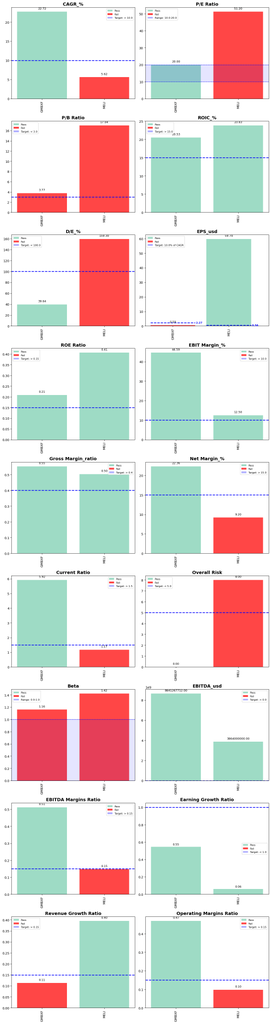

```python
# Plot financial Ratios
functions.plot_ratios(fa_df, ratio_criteria, plots_per_row = 2)
```

```python
# Generate the data
scorecard = functions.generate_scorecard(fa_df, ratio_criteria)

# Display with a gradient highlight on the Score column
print("\n--- STOCK SELECTION SCORECARD ---")
display(scorecard.style.background_gradient(subset=['Score %'], cmap='RdYlGn'))
```

| Ticker | CAGR_% | P/E Ratio | P/B Ratio | ROIC_% | D/E_% | EPS_usd | ROE Ratio | EBIT Margin_% | Gross Margin_ratio | Net Margin_% | Current Ratio | Overall Risk | Beta | EBITDA_usd | EBITDA Margins Ratio | Earning Growth Ratio | Revenue Growth Ratio | Operating Margins Ratio | Score % | Name | Sector | Industry |
| --- | --- | --- | --- | --- | --- | --- | --- | --- | --- | --- | --- | --- | --- | --- | --- | --- | --- | --- | --- | --- | --- | --- |
| GMBXF | ✅ | ✅ | ❌ | ✅ | ✅ | ❌ | ✅ | ✅ | ✅ | ✅ | ✅ | ✅ | ❌ | ✅ | ✅ | ✅ | ❌ | ✅ | 77.780000 | Grupo México, S.A.B. de C.V. | Basic Materials | Other Industrial Metals & Mining |
| MELI | ❌ | ❌ | ❌ | ✅ | ❌ | ✅ | ✅ | ✅ | ✅ | ❌ | ❌ | ❌ | ❌ | ✅ | ❌ | ✅ | ✅ | ❌ | 44.440000 | MercadoLibre, Inc. | Consumer Cyclical | Internet Retail |

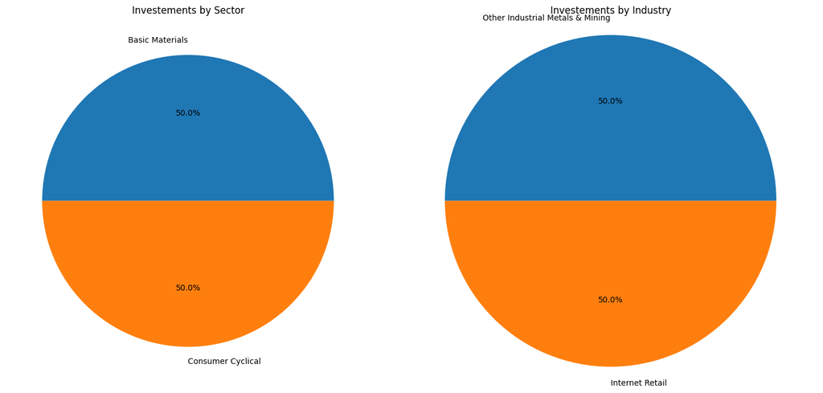

```python
# Sectors and Industries
functions.print_sector_industry(fa_df)
```

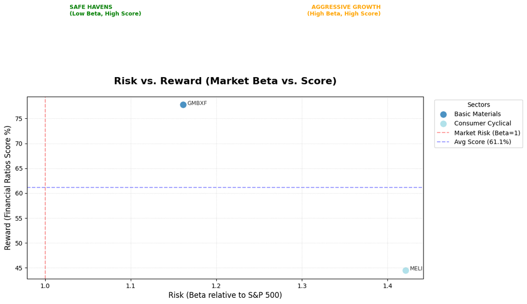

```python
# --- SCORE vs BETA by Sector ---
functions.plot_risk_reward(fa_df, ratio_criteria)
```

```python
# --- TOP N assets in all sectors ---
top_N_data = functions.get_top_N_assets(fa_df, ratio_criteria, top_n=10)
functions.plot_sector_treemap(top_N_data)

# Grouping the top 5 to see the distribution
summary = top_N_data.groupby(['Sector', 'Industry', 'Name', 'Ticker'])[['Score %']].max().sort_values('Score %', ascending=False)
display(summary.style.background_gradient(cmap='Greens'))
```

| Sector | Industry | Name | Ticker | Score % |
| --- | --- | --- | --- | --- |
| Basic Materials | Other Industrial Metals & Mining | Grupo México, S.A.B. de C.V. | GMBXF | 77.780000 |
| Consumer Cyclical | Internet Retail | MercadoLibre, Inc. | MELI | 44.440000 |

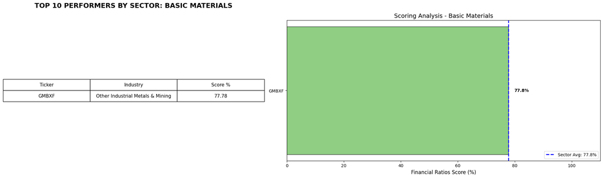

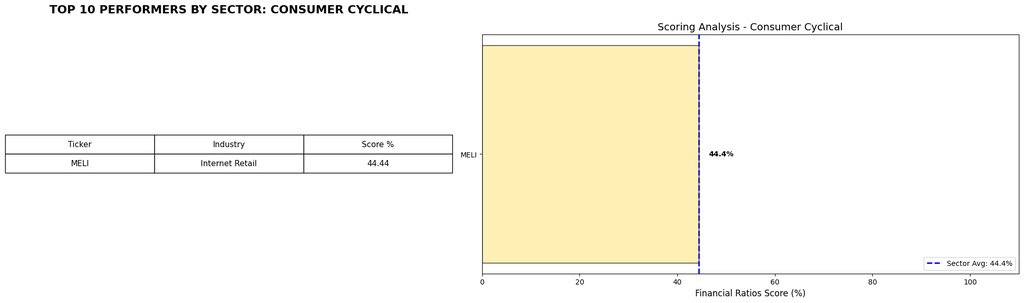

```python
# TOP N BY SECTOR AND INDUSTRY

functions.top_N_sector_industry(fa_df, ratio_criteria, n_per_sector=10)
```

```python
# TOP 1 BY SECTOR

final_picks = functions.top_1_sector(fa_df, ratio_criteria)
print("\n--- FINAL BEST-IN-CLASS PORTFOLIO SELECTION ---")
display(final_picks.style.hide(axis="index").background_gradient(subset=['Score %'], cmap='RdYlGn'))
```

| Sector | Industry | Ticker | Score % |
| --- | --- | --- | --- |
| Basic Materials | Other Industrial Metals & Mining | GMBXF | 77.780000 |
| Consumer Cyclical | Internet Retail | MELI | 44.440000 |

```python
#  Portfolio Summary - Beta and Scores

# Option A: All Assets
stats_all = functions.get_portfolio_summary(fa_df, ratio_criteria, mode="all")
display(stats_all.style.hide(axis="index"))

# Option B: Top 10 Overall
stats_top10 = functions.get_portfolio_summary(fa_df, ratio_criteria, mode="top_n", top_n=10)
display(stats_top10.style.hide(axis="index"))

# Option C: Top 1 per Sector
stats_sector = functions.get_portfolio_summary(fa_df, ratio_criteria, mode="sector_best")
display(stats_sector.style.hide(axis="index"))
```

| Metric | Value |
| --- | --- |
| Selection Strategy | ALL TICKERS |
| Total Tickers | 2 |
| Average Match Score | 61.11% |
| Average Beta | 1.29 |
| Portfolio Character | AGGRESSIVE / HIGH VOLATILITY |

| Metric | Value |
| --- | --- |
| Selection Strategy | TOP 10 OVERALL |
| Total Tickers | 2 |
| Average Match Score | 61.11% |
| Average Beta | 1.29 |
| Portfolio Character | AGGRESSIVE / HIGH VOLATILITY |

| Metric | Value |
| --- | --- |
| Selection Strategy | TOP 1 PER SECTOR |
| Total Tickers | 2 |
| Average Match Score | 61.11% |
| Average Beta | 1.29 |
| Portfolio Character | AGGRESSIVE / HIGH VOLATILITY |

# Fundamental Analysis ONE Ticker

**TS302_Stock Full Analysis.ipynb**

This section is to see in more detail any particular ticker

```python
# 1. Create the widget

ticker_dropdown = widgets.Dropdown(
    options=tickers,
    # options=["KOF", "AAPL", "MSFT", "MA","NVDA", "GOOGL", "AMZN", "META", "TSM","BRK-B", "V", "JPM", "XOM", "LLY", "MRK", "UNH", "PG", "MA","CVX", "KO", "PEP", "COST", "TMO", "ORCL", "CSCO", "NKE", "VZ", "ASML", "TXN", "ABT", "TM", "SAP", "AMD", "NFLX", "NOW", "ADBE", "LVMUY", "BABA", "SHEL", "TMUS", "QCOM", "PFE", "SNY", "AZN", "TOT", "GSK", "RIO", "BHP", "MCD"],
    #options=["BTC-USD", "ETH-USD", "USDT-USD", "XRP-USD", "LTC-USD", "ADA-USD", "DOT-USD", "BCH-USD", "XLM-USD", "LINK-USD"],
    value=tickers[0],  # Default selected value (must be from the options)
    description='Select Ticker:',
    disabled=False,
)

def on_change(selected_ticker):
    clear_output(wait=False)
    display(fa_df.loc[selected_ticker])

    global ticker_widget
    ticker_widget = selected_ticker

    return ticker_widget

# # 4. Link the function to the widget and capture the output
interactive_plot = widgets.interactive_output(on_change, {'selected_ticker': ticker_dropdown})

# # 5. Display the widget and the output area in your notebook cell
display(ticker_dropdown, interactive_plot)
```

```
Dropdown(description='Select Ticker:', options=('MELI', 'GMBXF'), value='MELI')
```

```
Output()
```

```python
# Choose any ticket from the list above
ticker = yf.Ticker(ticker_widget)
ticker_name = ticker.info.get('symbol')
print(ticker_name)
```

History

```python
# Example of history() of any ONE ticker for "1y"
hist = ticker.history(period="1y", auto_adjust=True)
print(ticker_name)
display(hist)
```

| Date | Open | High | Low | Close | Volume | Dividends | Stock Splits |
| --- | --- | --- | --- | --- | --- | --- | --- |
| 2025-01-16 00:00:00-05:00 | 1841.380005 | 1851.390015 | 1815.060059 | 1837.180054 | 242000 | 0.0 | 0.0 |
| 2025-01-17 00:00:00-05:00 | 1876.420044 | 1876.420044 | 1832.910034 | 1836.000000 | 245100 | 0.0 | 0.0 |
| 2025-01-21 00:00:00-05:00 | 1852.660034 | 1863.310059 | 1829.119995 | 1834.510010 | 262800 | 0.0 | 0.0 |
| 2025-01-22 00:00:00-05:00 | 1847.959961 | 1885.000000 | 1808.020020 | 1818.489990 | 402800 | 0.0 | 0.0 |
| 2025-01-23 00:00:00-05:00 | 1818.000000 | 1834.479980 | 1793.000000 | 1828.729980 | 267800 | 0.0 | 0.0 |
| ... | ... | ... | ... | ... | ... | ... | ... |
| 2026-01-09 00:00:00-05:00 | 2191.500000 | 2193.060059 | 2162.000000 | 2178.409912 | 309200 | 0.0 | 0.0 |
| 2026-01-12 00:00:00-05:00 | 2164.270020 | 2165.030029 | 2122.570068 | 2149.899902 | 408500 | 0.0 | 0.0 |
| 2026-01-13 00:00:00-05:00 | 2127.209961 | 2130.149902 | 2030.910034 | 2073.570068 | 689900 | 0.0 | 0.0 |
| 2026-01-14 00:00:00-05:00 | 2055.699951 | 2108.000000 | 2041.020020 | 2101.949951 | 500100 | 0.0 | 0.0 |
| 2026-01-15 00:00:00-05:00 | 2137.120117 | 2151.379883 | 2084.614990 | 2098.850098 | 423459 | 0.0 | 0.0 |

251 rows × 7 columns

- Info
- Income Statement
- Balance Sheet

```python
# info
ticker_info = ticker.info
# Optional: Print in JSON format all info
#print(json.dumps(ticker_info, indent=4))

#Income Statement
ticker_income_stmt = ticker.income_stmt
# Optional: Print Income Statement
#print(ticker_income_stmt)

#Balance Sheet
ticker_balance_sheet = ticker.balance_sheet
# Optional: Print Balance Sheet
#print(ticker_balance_sheet)


# To-Do: Support the Stock selection based on Ratios using the Financial Statements
```

```python
# Print info by category (some selected data only)

def print_info_by_category(info_list, name):
    print(f"\n{name}")
    for key in info_list:
        try:
            value = ticker_info.get(key, 'N/A')
            print(f"{key}: {value}")
        except Exception as e:
            print(f"Error retrieving '{key} for {ticker_name}: {e}")

# One can choose which info parameters to print in each category:
basic_info = ['symbol', 'longName', 'sector', 'industry', 'country']
market_info = ['currentPrice', 'marketCap', 'volume', '52WeekChange', 'fiftyTwoWeekHigh', 'fiftyTwoWeekLow']
financial_info = ['priceToBook', 'forwardPE', 'trailingPE', 'profitMargins', 'totalRevenue', 'debtToEquity',
                  'epsForward','ebitda','floatShares','forwardEps','grossMargins','grossProfits','operatingCashflow',
                  'operatingMargins','returnOnAssets','returnOnEquity','revenueGrowth','revenuePerShare','impliedSharesOutstanding',
                  'totalCash','totalDebt']
dividends_info = ['dividendYield','payoutRatio','dividendRate']
shares_info = ['heldPercentInsiders','heldPercentInstitutions']
technical_info = ['sharesOutstanding','beta','currency']

print_info_by_category(basic_info,      "1. Basic info:")
print_info_by_category(market_info,     "2. Market info:")
print_info_by_category(financial_info,  "3. Financial info:")
print_info_by_category(dividends_info,  "4. Dividends info:")
print_info_by_category(shares_info,     "5. Shares management info:")
print_info_by_category(technical_info,  "6. Technical info:")

# Market Cap = Current Share Price × Shares Outstanding
```

TO-DO: Monitorear Recompra o dilucion de acciones. Con base en el numero de acciones disponibles por anio

Dividends, Splits and Recommendations

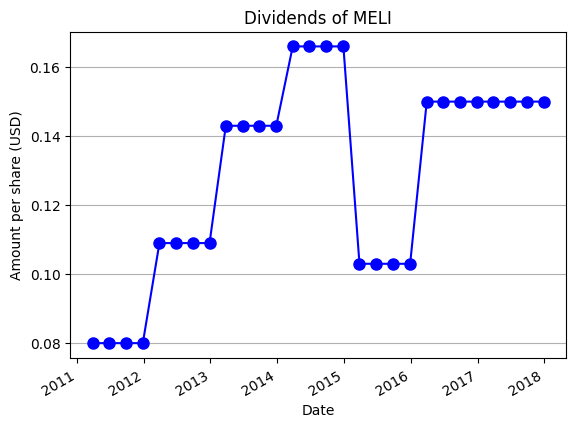

```
Date
2011-03-29 00:00:00-04:00    0.080
2011-06-28 00:00:00-04:00    0.080
2011-09-28 00:00:00-04:00    0.080
2011-12-28 00:00:00-05:00    0.080
2012-03-28 00:00:00-04:00    0.109
2012-06-27 00:00:00-04:00    0.109
2012-09-26 00:00:00-04:00    0.109
2012-12-27 00:00:00-05:00    0.109
2013-03-26 00:00:00-04:00    0.143
2013-06-26 00:00:00-04:00    0.143
2013-09-26 00:00:00-04:00    0.143
2013-12-27 00:00:00-05:00    0.143
2014-03-27 00:00:00-04:00    0.166
2014-06-26 00:00:00-04:00    0.166
2014-09-26 00:00:00-04:00    0.166
2014-12-29 00:00:00-05:00    0.166
2015-03-27 00:00:00-04:00    0.103
2015-06-26 00:00:00-04:00    0.103
2015-09-28 00:00:00-04:00    0.103
2015-12-29 00:00:00-05:00    0.103
2016-03-29 00:00:00-04:00    0.150
2016-06-28 00:00:00-04:00    0.150
2016-09-28 00:00:00-04:00    0.150
2016-12-28 00:00:00-05:00    0.150
2017-03-29 00:00:00-04:00    0.150
2017-06-28 00:00:00-04:00    0.150
2017-09-28 00:00:00-04:00    0.150
2017-12-28 00:00:00-05:00    0.150
Name: Dividends, dtype: float64
```

|  | period | strongBuy | buy | hold | sell | strongSell |
| --- | --- | --- | --- | --- | --- | --- |
| 0 | 0m | 5 | 18 | 3 | 0 | 0 |
| 1 | -1m | 5 | 18 | 3 | 0 | 0 |
| 2 | -2m | 5 | 18 | 3 | 0 | 0 |
| 3 | -3m | 5 | 18 | 3 | 0 | 0 |

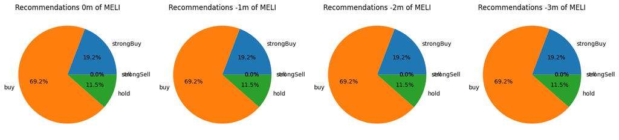

```python
# 7. Other info:
print("\n7. Other info:")
other_info = {'Dividends' : ticker.dividends,
              'Splits' : ticker.splits,
              'Recommendations' : ticker.recommendations
            #   'Recommendations Summary' : ticker.recommendations_summary
              }

functions.print_dividends_splits_recommendations(other_info, ticker_name)
```

```python
import operator
from dataclasses import dataclass
from typing import Callable, Any, Optional

RetrievalFunc = Callable[[dict], Any]   #ticker.info : is a dictionary: ticker.info.get('trailingPE', 'N/A'). Look for ticker_info =  ticker.info above
CompareFunc = Callable[[Any, Any], bool]

@dataclass
class FinancialRule:
    retrieval_func: RetrievalFunc   # function used to extract the specific metric from the data source
    metric_name: str
    target_value: Optional[Any] = None
    comparison_func: Optional[Callable[[Any, Any], bool]] = None
          # for printing pruposes
    # target_value: float             # The target value to compare against
    # comparison_func: CompareFunc    # comparison operator function (e.g., operator.lt for <)


# financial_rules = {
#     'D/E_%': FinancialRule(retrieval_func=lambda ticker_info: ticker_info.get('debtToEquity', 'N/A'), target_value=100.0, comparison_func=operator.gt, metric_name='D/E_%')
# }

financial_rules = {
    'Name':                     FinancialRule(retrieval_func=lambda ticker_info: ticker_info.get('longName', 'N/A'),            metric_name='Name'),
    'Sector':                   FinancialRule(retrieval_func=lambda ticker_info: ticker_info.get('sector', 'ETF, others'),      metric_name='Sector'),
    'Industry':                 FinancialRule(retrieval_func=lambda ticker_info: ticker_info.get('industry', 'ETF, others'),    metric_name='Industry'),
    'CAGR_%':                   FinancialRule(retrieval_func=lambda ticker_info: functions.get_cagr(ticker_info.get('symbol'), start_date, today),   target_value=10.0, comparison_func=operator.ge, metric_name='CAGR_%'),
    'P/E Ratio':                FinancialRule(retrieval_func=lambda ticker_info: ticker_info.get('trailingPE', 'N/A'),          target_value=25.0, comparison_func=operator.lt, metric_name='P/E Ratio'),
    'P/B Ratio':                FinancialRule(retrieval_func=lambda ticker_info: ticker_info.get('priceToBook', 'N/A'),         target_value=2.0, comparison_func=operator.lt, metric_name='P/B Ratio'),
    'ROIC_%':                   FinancialRule(retrieval_func=lambda ticker_info: functions.get_roic(ticker_info.get('symbol')), target_value=15.0, comparison_func=operator.gt, metric_name='ROIC_%'),
    'D/E_%':                    FinancialRule(retrieval_func=lambda ticker_info: ticker_info.get('debtToEquity', 'N/A'),        target_value=100.0, comparison_func=operator.lt, metric_name='D/E_%'),
    'EPS_usd':                  FinancialRule(retrieval_func=lambda ticker_info: ticker_info.get('epsForward', 'N/A'),          target_value=0.0, comparison_func=operator.gt, metric_name='EPS_usd'),
    'ROE Ratio':                FinancialRule(retrieval_func=lambda ticker_info: ticker_info.get('returnOnEquity', 'N/A'),      target_value=0.15, comparison_func=operator.ge, metric_name='ROE Ratio'),
    'EBIT Margin_%':            FinancialRule(retrieval_func=lambda ticker_info: functions.get_ebit_margin(ticker_info.get('symbol')),  target_value=10.0, comparison_func=operator.ge, metric_name='EBIT Margin_%'),
    'Gross Margin_ratio':       FinancialRule(retrieval_func=lambda ticker_info: ticker_info.get('grossMargins', 'N/A'),        target_value=0.40, comparison_func=operator.ge, metric_name='Gross Margin_ratio'),
    'Net Margin_%':             FinancialRule(retrieval_func=lambda ticker_info: functions.get_net_margin(ticker_info.get('symbol')),   target_value=15.0, comparison_func=operator.ge, metric_name='Net Margin_%'),
    'Current Ratio':            FinancialRule(retrieval_func=lambda ticker_info: ticker_info.get('currentRatio', 'N/A'),        target_value=1.5, comparison_func=operator.ge, metric_name='Current Ratio'),
    'Overall Risk':             FinancialRule(retrieval_func=lambda ticker_info: ticker_info.get('overallRisk', 'N/A'),         target_value=5.0, comparison_func=operator.lt, metric_name='Overall Risk'),
    'Beta':                     FinancialRule(retrieval_func=lambda ticker_info: ticker_info.get('beta', 'N/A'),                target_value=1.0, comparison_func=operator.eq, metric_name='Beta'),
    'EBITDA_usd':               FinancialRule(retrieval_func=lambda ticker_info: ticker_info.get('ebitda', 'N/A'),              target_value=0.0, comparison_func=operator.gt, metric_name='EBITDA_usd'),
    'EBITDA Margins Ratio':     FinancialRule(retrieval_func=lambda ticker_info: ticker_info.get('ebitdaMargins', 'N/A'),       target_value=0.15, comparison_func=operator.gt, metric_name='EBITDA Margins Ratio'),
    'Earning Growth Ratio':     FinancialRule(retrieval_func=lambda ticker_info: ticker_info.get('earningsGrowth', 'N/A'),      target_value=0.15, comparison_func=operator.gt, metric_name='Earning Growth Ratio'),
    'Revenue Growth Ratio':     FinancialRule(retrieval_func=lambda ticker_info: ticker_info.get('revenueGrowth', 'N/A'),       target_value=0.15, comparison_func=operator.gt, metric_name='Revenue Growth Ratio'),
    'Operating Margins Ratio':  FinancialRule(retrieval_func=lambda ticker_info: ticker_info.get('operatingMargins', 'N/A'),    target_value=0.15, comparison_func=operator.gt, metric_name='Operating Margins Ratio'),
}

def evaluate_ticker_rules(financial_rules: dict, ticker_info: dict):
    print(f"---Evaluating Rules for {ticker_info.get('symbol', 'Unknown Ticker')}---")

    if not ticker_info.get('symbol'):
        print("Status: ⚠️ SKIP (No ticker data available)")
        return

    for rule_name, rule in financial_rules.items():
        # 1. Call the stored retrieval function to get the actual metric value
        actual_value = rule.retrieval_func(ticker_info)

        print(f"\nRule: {rule_name}")
        print(f"Metric: {rule.metric_name}, Value found: {actual_value}")


        if rule.comparison_func is not None:
            if actual_value is None or actual_value == 'N/A':
                print("Status: ⚠️ SKIP (Data for comparison not available)")
                continue

            # 2. Call the stored comparison function
            is_pass = rule.comparison_func(actual_value, rule.target_value)

            if is_pass:
                print(f"Status: ✅ PASS ({actual_value} is acceptable)")
            else:
                print(f"Status: ❌ FAIL ({actual_value} fails rule to be {rule.comparison_func.__name__} {rule.target_value})")

        else:
            print("Status: ✅ INFO (No comparison needed)")

evaluate_ticker_rules(financial_rules, ticker_info)
```

# All Tickers in Portfolio

## Import Prices from yfinance (All Tickers)

**TS302_Stock Full Analysis.ipynb**

```python
# import data from yahoo Finance
print(f"Number of days since Brokerage account was opened: {no_days}")
df = yf.download(tickers, start=start_date, end=today, auto_adjust=True)
df.info()
```

```
[*********************100%***********************]  2 of 2 completed
```

## Prices (Close)

```python
prices_raw = df["Close"]
print('-- Last 5 days of prices --')
display(prices_raw.tail(5))
```

| Ticker Date | GMBXF | MELI |
| --- | --- | --- |
| 2026-01-08 | 9.78 | 2179.800049 |
| 2026-01-09 | 10.22 | 2178.409912 |
| 2026-01-12 | 10.63 | 2149.899902 |
| 2026-01-13 | 10.75 | 2073.570068 |
| 2026-01-14 | 11.05 | 2101.949951 |

```python
# drop NaN (days without price)
prices = prices_raw.dropna()
display(prices.tail(5))
```

| Ticker Date | GMBXF | MELI |
| --- | --- | --- |
| 2026-01-08 | 9.78 | 2179.800049 |
| 2026-01-09 | 10.22 | 2178.409912 |
| 2026-01-12 | 10.63 | 2149.899902 |
| 2026-01-13 | 10.75 | 2073.570068 |
| 2026-01-14 | 11.05 | 2101.949951 |

```python
print(f"prices_raw shape: {prices_raw.shape}")
print(f"prices shape: {prices.shape}")

if len(prices) < len(prices_raw):
    print(f"Reduction of {(len(prices_raw) - len(prices))}")
    print(f"It can be noticed that the amount of rows in the dataframe dropped from {len(prices_raw)} to {len(prices)} after the drop.na() operation. This is because there are a couple of assets that are relatively new in the public market (post IPO).")
```

```python
print(f"Reminder: the original 'start_date' was: {start_date.date().strftime("%B %d, %Y")}, when the original portfolio was created.")

df_ = df['Close']
first_valid_dates = df_.apply(pd.Series.first_valid_index)
first_valid_dates.name = "First Valid Date"
first_valid_dates = first_valid_dates.sort_values(ascending=False)


print(f"\nThe asset with the smallest amount of data available is: '{first_valid_dates.index[0]}' starting from '{first_valid_dates.iloc[0].date().strftime("%B %d, %Y")}' only.")

print("\nOldest available dates for each asset:")
display(first_valid_dates)
```

```
Ticker
GMBXF   2021-04-26
MELI    2021-04-26
Name: First Valid Date, dtype: datetime64[ns]
```

```python
# -- PLOT ASSET PRICES --
functions.plot_prices(prices=prices, yaxis_label="Price (USD)")
```

## Stats (describe)

```python
# statistics about prices
prices.describe()
```

| Ticker | GMBXF | MELI |
| --- | --- | --- |
| count | 1187.000000 | 1187.000000 |
| mean | 4.817137 | 1545.265932 |
| std | 1.372546 | 488.124554 |
| min | 2.786575 | 612.700012 |
| 25% | 3.868857 | 1180.909973 |
| 50% | 4.551509 | 1529.160034 |
| 75% | 5.226378 | 1951.325012 |
| max | 11.050000 | 2613.629883 |

## Normalized Prices

**Normalize to 100**

**Normalizar** precios de diferentes **magnitudes** dividiendo entre el primer registro. Todos los precios parten del mismo punto que es el 100.

$$ \frac {P_t}{P_0} * 100 $$

Nota: esto ya no es mas el Precio al Cierre sino un indice de crecimiento en el tiempo.

```python
# Normalized Prices

prices_normalized = (prices / prices.iloc[0]) * 100


# -- PLOT ASSET PRICES --
functions.plot_prices(prices=prices_normalized, yaxis_label="Price (USD)")
```

## Daily Returns

**TS303_yfinance Indices Bursatiles.ipynb**

Normal (simple or arithmetic) returns:

$$Return(R_t) = \frac{P_t - P_{t-1}}{P_{t-1}} = \frac {P_t}{P_{t-1}} -1 $$

```python
# Daily Returns. Using pct_change()
# Normal (simple or arithmetic) returns
# Expresed in FRACTION.
# If Percentage is needed then multiply by 100.
daily_returns = prices.pct_change(fill_method=None)
daily_returns = daily_returns.dropna()
daily_returns.tail(5)
```

| Ticker Date | GMBXF | MELI |
| --- | --- | --- |
| 2026-01-08 | -0.012121 | 0.007949 |
| 2026-01-09 | 0.044990 | -0.000638 |
| 2026-01-12 | 0.040117 | -0.013088 |
| 2026-01-13 | 0.011289 | -0.035504 |
| 2026-01-14 | 0.027907 | 0.013686 |

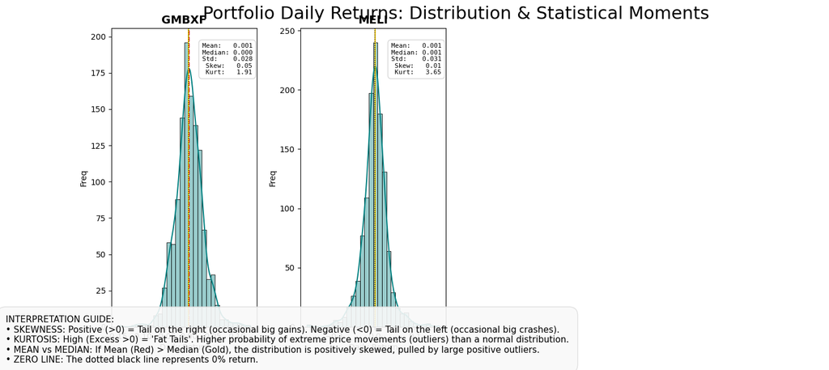

| Ticker | Mean | Median | Std Dev | Skewness | Kurtosis |
| --- | --- | --- | --- | --- | --- |
| MELI | 0.0007 | 0.0013 | 0.0315 | 0.0107 | 3.6494 |
| GMBXF | 0.0012 | 0.0000 | 0.0283 | 0.0474 | 1.9056 |

```python
results_df = functions.plot_returns_distributions(daily_returns, num_cols=4)
```

```python
# -- PLOT DAILY RETURNS --
functions.plot_daily_returns(daily_returns)
```

## Summary of Daily Returns

```python
# stats and summary of daily retutns
print(f"Number of days of evaluation: {(today - daily_returns.index[0]).days}")
print(f"since {daily_returns.index[0].date().strftime("%B %d, %Y")} until {today.date().strftime("%B %d, %Y")}")

max_daily_return = daily_returns.describe().loc['max'].sort_values(ascending=False)
print(f"\nThe asset with the biggest Return in a single day is '{max_daily_return.index[0]}' with {100*max_daily_return.iloc[0]:,.5}%")

min_daily_return = daily_returns.describe().loc['min'].sort_values(ascending=True)
print(f"The asset with the lowest Return in a single day is '{min_daily_return.index[0]}' with {100*min_daily_return.iloc[0]:,.5}%")

average_daily_returns = daily_returns.mean()
print(f"The average of all Daily Returns is {average_daily_returns.mean()*100:,.4}%")

max_std = daily_returns.describe().loc['std'].sort_values(ascending=False)
print(f"\nThe asset with the biggest StdDev in Daily Returns is '{max_std.index[0]}' with {100*max_std.iloc[0]:,.5}%")
print(f"The asset with the smallest StdDev in Daily Returns is '{max_std.index[-1]}' with {100*max_std.iloc[-1]:,.5}%")
```

## Annualized Returns

```python
# Annualized Returns
annualized_return_tickers = daily_returns.mean() * 250
annualized_return_tickers.name = "Annualized Returns:"
annualized_return_tickers = annualized_return_tickers.sort_values(ascending=False)
print("Annualized Returns (%):")
print(f"{round(annualized_return_tickers, 2)* 100}")
```

## Cumulative Returns in Period

**TS303_yfinance Indices Bursatiles.ipynb**

```python
# cumprod(): calculates the total return over a period by compounding the daily returns. (a)(ab)(abc)
# It reflects how an initial investment would grow if it were continuously reinvested and earned the daily returns.
cumulative_returns = (1 + daily_returns).cumprod()
cumulative_returns = (cumulative_returns - 1)*100
print("Cumulative Returns in %:")
cumulative_returns.tail(5)
```

| Ticker Date | GMBXF | MELI |
| --- | --- | --- |
| 2026-01-08 | 133.066848 | 34.306014 |
| 2026-01-09 | 143.552486 | 34.220362 |
| 2026-01-12 | 153.323179 | 32.463749 |
| 2026-01-13 | 156.182892 | 27.760769 |
| 2026-01-14 | 163.332187 | 29.509365 |

```python
# -- PLOT CUMULATIVE RETURNS --
functions.plot_cumulative_returns(cumulative_returns)
```

## Final Cumulated Returns in Period

```python
# Rendimientos Acumulados al Final del Tiempo en (%) use .prod() y -1
print(f"Final Cumulative Returns in (%) in {(today - daily_returns.index[0]).days} days of evaluation: ")
print(f"since {daily_returns.index[0].date().strftime("%B %d, %Y")} until {today.date().strftime("%B %d, %Y")}")

cumulative_returns_final = cumulative_returns.iloc[-1]
cumulative_returns_final.name = "Final Cumulative Returns (%)"
cumulative_returns_final = round(cumulative_returns_final.sort_values(ascending=False) , 1)
print("Final Cumulative Returns in %:")
display(cumulative_returns_final.all)
```

```
<bound method Series.all of Ticker
GMBXF    163.3
MELI      29.5
Name: Final Cumulative Returns (%), dtype: float64>
```

## Summary Final Cumulated Returns

```python
print(f"Number of days of evaluation (period): {(today - cumulative_returns.index[0]).days}")
print(f"From {cumulative_returns.index[0].date().strftime("%B %d, %Y")} until {today.date().strftime("%B %d, %Y")}")

print(f"The asset with the best cumulated return in the Period '{cumulative_returns_final.index[0]}' with {cumulative_returns_final.iloc[0]:,.5}% in the period")
print(f"The asset with the worst cumulative return in the Period '{cumulative_returns_final.index[-1]}' with {cumulative_returns_final.iloc[-1]:,.5}% in the period")
```

## Risk, Annualized Volatility

**TS303_yfinance Indices Bursatiles.ipynb**

Asset Volatility (risk or std)

$$ \sigma = risk = \sqrt{\frac {\sum(r - \bar{r})^2}{n-1}} $$

```python
# Yearly volatility (risk)

# StdDev of daily returns in a 252-days year
annualized_volatility = daily_returns.std() * np.sqrt(252)

# Percentage (%)
annualized_volatility_percent = annualized_volatility * 100

# DataFrame of Annualized Volatility
volatility_df = pd.DataFrame(annualized_volatility_percent, columns=["Volatility (%)"])

print("Annualized Assets Volatility:")

volatility_df = round(volatility_df.sort_values(by="Volatility (%)", ascending=False), 2)

display(volatility_df)
```

| Ticker | Volatility (%) |
| --- | --- |
| MELI | 49.96 |
| GMBXF | 44.91 |

Stats of Volatility

```python
display(volatility_df.describe()) # all stocks
```

|  | Volatility (%) |
| --- | --- |
| count | 2.000000 |
| mean | 47.435000 |
| std | 3.570889 |
| min | 44.910000 |
| 25% | 46.172500 |
| 50% | 47.435000 |
| 75% | 48.697500 |
| max | 49.960000 |

## Summary Risk, Volatility

```python
# summary and stats

print(f"Number of days of evaluation: {(today - cumulative_returns.index[0]).days}")
print(f"From {cumulative_returns.index[0].date().strftime("%B %d, %Y")} until {today.date().strftime("%B %d, %Y")}")

print(f"The asset with the biggest Annualized Volatility is '{volatility_df.index[0]}' with a {volatility_df.iloc[0].values[0]:,.5} %")
print(f"The asset with the lowest Annualized Volatility is '{volatility_df.index[-1]}' with a {volatility_df.iloc[-1].values[0]:,.5} %")
print(f"The Average Annualized Volatility of all assets is: {volatility_df.mean().values[0]:,.5} %")
```

## Dividend Yields (%)

```python
# ANNUAL DIVIDEND YIELDS
yields = functions.plot_annual_dividnd_yields(daily_returns)
```

```
GMBXF    2.97
MELI     0.00
Name: dividendYield, dtype: float64
```

# Initial Portfolio (Original)

## Assets Weights

Compute Assets weights from the original portfolio

```python
# call the original portfolio [Ticker, Current QTY]
file_df

# Close prices df
close_prices = prices.iloc[-1]
close_prices.name = "Close Price"

# Merge original df with Close Prices
weights_df = pd.merge(file_df, close_prices, on='Ticker', how='inner')

# Add column of Amount Invested for each asset
weights_df['Investment'] = weights_df["Current QTY"] * weights_df["Close Price"]

# Calculate the Total Invested
Total_invested = weights_df['Investment'].sum()
print(f"Total Invested: ${Total_invested:,.2f}")

# Add column of weights of each asset
weights_df['Weights'] = weights_df['Investment'] / Total_invested
print(f"The sum of the weights is: {weights_df['Weights'].sum()}")

weights_df.set_index('Ticker', inplace=True)
weights_df.sort_values(by='Investment', ascending=False, inplace=True)
print("Sorted by Invested amount ($):")
display(round(weights_df, 2))
```

| Ticker | Current QTY | Close Price | Investment | Weights |
| --- | --- | --- | --- | --- |
| MELI | 100 | 2101.95 | 210195.0 | 0.99 |
| GMBXF | 100 | 11.05 | 1105.0 | 0.01 |

TO-DO: Grafica de Pastel con los Porcentajes

Grafica por Sectores, Industrias

## Portfolio Daily Returns

```python
#checking the shapes of the objects to multiply
# Daily Returns Expresed in FRACTION.
print("Portfolio daily returns = [Daily Returns] x [weights]")
print(f"daily_returns shape: {daily_returns.shape}")
print(f"weights_df shape: {weights_df['Weights'].shape}")
print(f"Matrix multiplication [{daily_returns.shape[0]} x {daily_returns.shape[1]}] x [{weights_df['Weights'].shape[0]} x 1] = [{daily_returns.shape[0]} x 1]")
```

```python
# option 1: Portfolio's Daily Returns: Matrix multiplication (see above)
portfolio_daily_returns = (daily_returns @ weights_df['Weights'])

# option 2: Portfolio's Daily Returns: weighted sum of the daily returns of each asset
# portfolio_daily_returns = (daily_returns * weights_df['Weights']).sum(axis=1)


portfolio_daily_returns.name = 'portfolio daily returns'
print("portfolio_daily_returns:")
display(portfolio_daily_returns) # Expresed in FRACTION (not percentage)
```

```
Date
2021-04-27   -0.011096
2021-04-28    0.010351
2021-04-29   -0.020933
2021-04-30   -0.011081
2021-05-03    0.000395
                ...
2026-01-08    0.007844
2026-01-09   -0.000399
2026-01-12   -0.012809
2026-01-13   -0.035259
2026-01-14    0.013761
Name: portfolio daily returns, Length: 1186, dtype: float64
```

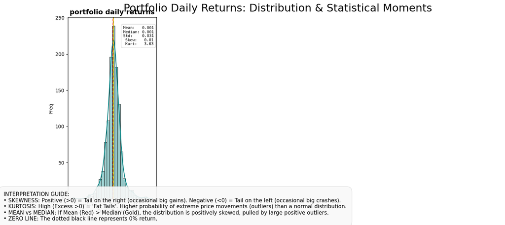

| Ticker | Mean | Median | Std Dev | Skewness | Kurtosis |
| --- | --- | --- | --- | --- | --- |
| portfolio daily returns | 0.0007 | 0.0012 | 0.0313 | 0.0106 | 3.6335 |

```python
results_df = functions.plot_returns_distributions(pd.DataFrame(portfolio_daily_returns), num_cols=4)
```

```python
# -- PLOT DAILY RETURNS --
functions.plot_daily_returns(pd.DataFrame(portfolio_daily_returns))
```

## Portfolio Annualized Returns

```python
# Annualized Returns
annualized_return_portfolio = portfolio_daily_returns.mean() * 250
print("Annualized Returns (%):")
print(f"{round(annualized_return_portfolio, 2) * 100}%")
```

## Portfolio Cumulative Returns

```python
# Portfolio's Cumulative daily Returns
portfolio_cumulative_returns = (1 + portfolio_daily_returns).cumprod()
portfolio_cumulative_returns = (portfolio_cumulative_returns - 1) * 100
portfolio_cumulative_returns = portfolio_cumulative_returns.rename('portfolio cumulative returns')
print("Portfolio Daily Cumulative Returns:")
display(portfolio_cumulative_returns)
```

```
Date
2021-04-27    -1.109565
2021-04-28    -0.085933
2021-04-29    -2.177476
2021-04-30    -3.261423
2021-05-03    -3.223212
                ...
2026-01-08    35.298223
2026-01-09    35.244222
2026-01-12    33.511839
2026-01-13    28.804319
2026-01-14    30.576776
Name: portfolio cumulative returns, Length: 1186, dtype: float64
```

```python
# -- PLOT CUMULATIVE RETURNS --
functions.plot_cumulative_returns(pd.DataFrame(portfolio_cumulative_returns))
```

Portfolio Cumulative Final

```python
# Portfolio's final comulated return
portafolio_cumulative_final = portfolio_cumulative_returns.iloc[-1]
print(f"portafolio_cumulative Returns_final: {portafolio_cumulative_final:,.4}%")
```

## Portfolio Volatility (Annualized)

```python
# Compute annualized Volatility of the Portfolio
portfolio_annualized_volatility = portfolio_daily_returns.std() * np.sqrt(252)

# Convert to percentage
portfolio_annualized_volatility_perc = portfolio_annualized_volatility * 100

print(f"Portfolio Annualized Volatility: {portfolio_annualized_volatility_perc:,.4}%")
```

## Portfolio Sharpe Ratio

$$ Sharpe = \frac{R_p - R_f}{\sigma_p} = \frac{\mu_p - r_f}{\sigma_p}$$

Where:

- $R_p$: Expected Portfolio Return, $\mu$ (average rate of return)
- $R_f$: Risk Free Rate (can be 0 if ignored)
- $\sigma_p$: Portfolio Risk (StdDev) Standard Deviation of the portfolio's excess return.

```python
portfolio_annualized_return = portfolio_daily_returns.mean()*252 #Annualized
portfolio_sr = round((portfolio_annualized_return - (risk_free))/portfolio_annualized_volatility, 2)
print(f"Portfolio Sharpe Ratio: {portfolio_sr}")
```

## Summary

```python
print(f"Number of days of evaluation: {(today - cumulative_returns.index[0]).days} days")
print(f"From {cumulative_returns.index[0].date().strftime("%B %d, %Y")} until {today.date().strftime("%B %d, %Y")}")

print(f"\nTotal Invested: ${Total_invested:,.2f}")
print(f"Portafolio_cumulative returns_final (all period): {portafolio_cumulative_final:,.4}%")
print(f"Portfolio Annualized Average Returns: {portfolio_annualized_return:,.4%}")
print(f"Portfolio Annualized Volatility: {portfolio_annualized_volatility_perc:,.4}%")
print(f"Portfolio Sharpe Ratio: {portfolio_sr}")
```

# Benchmarks (Indices)

## Daily Index Levels

```python
# Benchmark Indices
benchmark_indices = {
    "EE.UU. (S&P 500)": "^GSPC",
    "EE.UU. (NASDAQ)": "^IXIC",
    "EE.UU. (DJIA)": "^DJI",
    "EE.UU. (Russell 100)": "^RUI",
    "México (IPC)": "^MXX",
    "Japón (Nikkei 225)": "^N225",
    "Alemania (DAX)": "^GDAXI",
    "Reino Unido (FTSE 100)": "^FTSE"
}

# get data from yahoo finance
benchmarks_prices = yf.download(list(benchmark_indices.values()), start=first_valid_dates.iloc[0], end=today, auto_adjust=True)["Close"]

# Rename columns
benchmarks_prices.columns = list(benchmark_indices.keys())

print("Benchmark Indices levels:")
display(benchmarks_prices.tail(5))
```

```
[*********************100%***********************]  8 of 8 completed
```

[output not shown]

```python
# -- PLOT ASSET PRICES --
functions.plot_prices(prices=benchmarks_prices, yaxis_label="Index Level")
```

## Normalized Index Levels

```python
# Normalized Index Levels
benchmarks_prices_normalized = (benchmarks_prices / benchmarks_prices.iloc[0]) * 100

# -- PLOT ASSET PRICES --
functions.plot_prices(prices=benchmarks_prices_normalized, yaxis_label="Index Level")
```

## Daily Returns

```python
# Daily Returns
daily_returns_bm = benchmarks_prices.pct_change(fill_method=None)

# limpieza básica de daily_returns (elimina la primera fila con NaN)
daily_returns_bm = daily_returns_bm.dropna()
daily_returns_bm.tail(5)
```

| Date | EE.UU. (S&P 500) | EE.UU. (NASDAQ) | EE.UU. (DJIA) | EE.UU. (Russell 100) | México (IPC) | Japón (Nikkei 225) | Alemania (DAX) | Reino Unido (FTSE 100) |
| --- | --- | --- | --- | --- | --- | --- | --- | --- |
| 2026-01-06 | 0.009900 | 0.011805 | 0.000945 | 0.006197 | 0.006469 | 0.000121 | 0.013221 | 0.006450 |
| 2026-01-07 | -0.009421 | -0.007360 | 0.009242 | -0.003440 | 0.001576 | -0.002315 | -0.010589 | -0.003535 |
| 2026-01-08 | 0.005511 | -0.000348 | 0.000207 | 0.000077 | -0.004421 | 0.010009 | -0.016256 | 0.000074 |
| 2026-01-09 | 0.004830 | 0.007954 | 0.005340 | 0.006475 | 0.008149 | 0.008266 | 0.016093 | 0.006269 |
| 2026-01-14 | -0.000861 | 0.004636 | -0.005288 | -0.005333 | -0.010043 | 0.016064 | 0.014791 | -0.004952 |

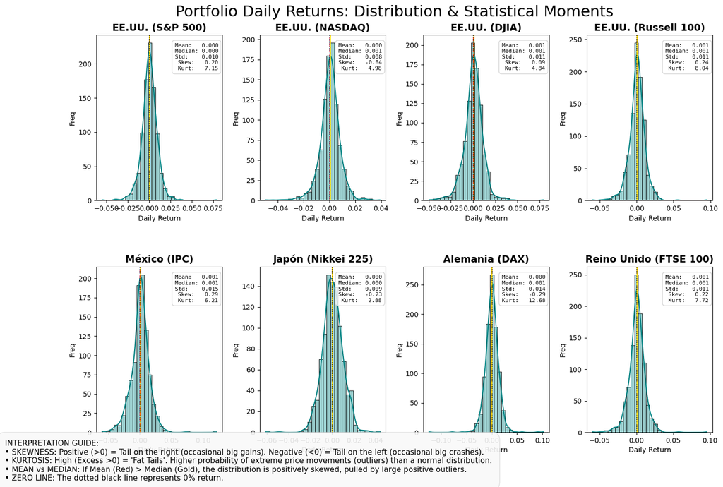

| Ticker | Mean | Median | Std Dev | Skewness | Kurtosis |
| --- | --- | --- | --- | --- | --- |
| Alemania (DAX) | 0.0004 | 0.0007 | 0.0140 | -0.2912 | 12.6830 |
| EE.UU. (Russell 100) | 0.0005 | 0.0009 | 0.0111 | 0.2379 | 8.0382 |
| Reino Unido (FTSE 100) | 0.0005 | 0.0007 | 0.0113 | 0.2242 | 7.7171 |
| EE.UU. (S&P 500) | 0.0004 | 0.0004 | 0.0095 | 0.2033 | 7.1519 |
| México (IPC) | 0.0007 | 0.0013 | 0.0147 | 0.2939 | 6.2097 |
| EE.UU. (NASDAQ) | 0.0003 | 0.0007 | 0.0080 | -0.6407 | 4.9840 |
| EE.UU. (DJIA) | 0.0005 | 0.0009 | 0.0108 | 0.0892 | 4.8448 |
| Japón (Nikkei 225) | 0.0004 | 0.0002 | 0.0095 | -0.2327 | 2.8813 |

```python
results_df = functions.plot_returns_distributions(daily_returns_bm, num_cols=4)
```

```python
functions.plot_daily_returns(daily_returns_bm)
```

## Annualized Returns

```python
# Annualized Returns
annualized_return_bm = daily_returns_bm.mean() * 252
annualized_return_bm.name = "Annualized Returns (%):"
annualized_return_bm = annualized_return_bm.sort_values(ascending=False)
print("Annualized Returns (%):")
print(round(annualized_return_bm, 2)*100)
```

## Cumulative Daily Returns

```python
cumulative_returns_bm = (1 + daily_returns_bm).cumprod()
cumulative_returns_bm = (cumulative_returns_bm - 1) * 100
display(cumulative_returns_bm.tail(5))
```

| Date | EE.UU. (S&P 500) | EE.UU. (NASDAQ) | EE.UU. (DJIA) | EE.UU. (Russell 100) | México (IPC) | Japón (Nikkei 225) | Alemania (DAX) | Reino Unido (FTSE 100) |
| --- | --- | --- | --- | --- | --- | --- | --- | --- |
| 2026-01-06 | 34.248604 | 33.539066 | 55.726740 | 55.400121 | 71.853038 | 40.797690 | 36.248583 | 51.833991 |
| 2026-01-07 | 32.983799 | 32.556259 | 57.166009 | 54.865557 | 72.123871 | 40.471716 | 34.805889 | 51.297228 |
| 2026-01-08 | 33.716711 | 32.510087 | 57.198548 | 54.877411 | 71.362958 | 41.877723 | 32.614420 | 51.308437 |
| 2026-01-09 | 34.362578 | 33.564123 | 58.037982 | 55.880318 | 72.759331 | 43.050503 | 34.748581 | 52.257065 |
| 2026-01-14 | 34.246878 | 34.183366 | 57.202305 | 55.048952 | 71.024303 | 45.348492 | 36.741709 | 51.503084 |

```python
functions.plot_cumulative_returns(cumulative_returns_bm)
```

```python
# Final Cumulative Return in the period of evaluation for all Indices
print("Final Cumulative Returns (%)")
# cumulative_returns_final_bm = (1 + daily_returns_bm).prod() -1
cumulative_returns_final_bm = cumulative_returns_bm.iloc[-1]
cumulative_returns_final_bm = cumulative_returns_final_bm.sort_values(ascending=False)
cumulative_returns_final_bm = cumulative_returns_final_bm.rename("final cumulative returns Benchmarks (%)")
display(cumulative_returns_final_bm)
```

```
México (IPC)              71.024303
EE.UU. (DJIA)             57.202305
EE.UU. (Russell 100)      55.048952
Reino Unido (FTSE 100)    51.503084
Japón (Nikkei 225)        45.348492
Alemania (DAX)            36.741709
EE.UU. (S&P 500)          34.246878
EE.UU. (NASDAQ)           34.183366
Name: final cumulative returns Benchmarks (%), dtype: float64
```

## Volatility

```python
#Annualized Volatility
annualized_volatility_bm = daily_returns_bm.std() * np.sqrt(252)

#Annualized Volatility Percentage
annualized_volatility_bm_perc = annualized_volatility_bm * 100

annualized_volatility_bm_perc.rename('Volatility Benchmarks (%)', inplace=True)

print("Volatility of Benchmark Indices (%):")
annualized_volatility_bm_perc.sort_values(ascending=False, inplace=True)
display(annualized_volatility_bm_perc)
```

```
México (IPC)              23.318459
Alemania (DAX)            22.176649
Reino Unido (FTSE 100)    17.877556
EE.UU. (Russell 100)      17.542846
EE.UU. (DJIA)             17.213699
EE.UU. (S&P 500)          15.093692
Japón (Nikkei 225)        15.049194
EE.UU. (NASDAQ)           12.722783
Name: Volatility Benchmarks (%), dtype: float64
```

## Sharpe Ratios

$$ Sharpe = \frac{R_p - R_f}{\sigma_p} = \frac{\mu_p - r_f}{\sigma_p}$$

Where:

- $R_p$: Expected Portfolio Return, $\mu$
- $R_f$: Risk Free Rate (can be 0 if ignored)
- $\sigma_p$: Portfolio Risk (StdDev)

```python
# Sharpe Ratios
benchmark_sr = round((annualized_return_bm - (risk_free))/annualized_volatility_bm, 2)
benchmark_sr.rename('Sharpe Ratio', inplace=True)
benchmark_sr.sort_values(ascending=False, inplace=True)
display(benchmark_sr)
```

```
EE.UU. (DJIA)             0.61
México (IPC)              0.60
EE.UU. (Russell 100)      0.58
Japón (Nikkei 225)        0.53
Reino Unido (FTSE 100)    0.53
EE.UU. (NASDAQ)           0.43
EE.UU. (S&P 500)          0.38
Alemania (DAX)            0.34
Name: Sharpe Ratio, dtype: float64
```

## Summary

```python
# Days of evaluation
no_days_compare = today.date() - first_valid_dates.iloc[0].date()
print(f"\nNumber of days of evaluation: {no_days_compare.days} days.")
print(f"From: {first_valid_dates.iloc[0].date().strftime("%B %d, %Y")} to: {today.date().strftime("%B %d, %Y")}")

# Summary Return and Volatility
print("\nSummary: Benchmark Indices:")
print(f"'{cumulative_returns_final_bm.index[0]}' has the largest total return {cumulative_returns_final_bm.iloc[0]:,.5}%")
print(f"and'{cumulative_returns_final_bm.index[-1]}' the lowest total return {cumulative_returns_final_bm.iloc[-1]:,.3}%")
print(f"\n'{annualized_volatility_bm_perc.index[0]}' has the largest volatility {annualized_volatility_bm_perc.iloc[0]:,.5}%")
print(f"and '{annualized_volatility_bm_perc.index[-1]}' the lowest volatility {annualized_volatility_bm_perc.iloc[-1]:,.5}%")
```

# Compare Initial Portfolio and Indices

## Daily Returns

Combine dataframes

```python
# Combine Daily Returns of Initial Porfolio and
# Benchmark Indices in a single dataFrame to plot

# convert portfolio_daily_returns to datafre to merge it with Indices daily returns
portfolio_daily_returns_df = pd.DataFrame(portfolio_daily_returns)
portfolio_daily_returns_df.rename(columns={'portfolio daily returns':'Initial Portfolio'}, inplace=True)

# check if the lenghts of the dataframes match
if len(portfolio_daily_returns_df) != len(daily_returns_bm):
    print(f"Lengths of DataFrames don't match {len(portfolio_daily_returns_df)} vs {len(daily_returns_bm)} but a left merge will help")
    print("There are more dates in one dataframe than the other")


# Merge Daily Returns of Benchmark Indices and Initial Portfolio
# Note: Left-Merge on Benchmark daily returns because they don't operate on weekends or bank holidays
# thus we compare both benchmark and portfolio using the same labor day dates only.
merge_daily_returns = pd.merge(daily_returns_bm, portfolio_daily_returns_df, on='Date', how="left")
print("\nDaily Returns (merged portfolio and indices):")
display(merge_daily_returns.tail(5))
```

| Date | EE.UU. (S&P 500) | EE.UU. (NASDAQ) | EE.UU. (DJIA) | EE.UU. (Russell 100) | México (IPC) | Japón (Nikkei 225) | Alemania (DAX) | Reino Unido (FTSE 100) | Initial Portfolio |
| --- | --- | --- | --- | --- | --- | --- | --- | --- | --- |
| 2026-01-06 | 0.009900 | 0.011805 | 0.000945 | 0.006197 | 0.006469 | 0.000121 | 0.013221 | 0.006450 | 0.017867 |
| 2026-01-07 | -0.009421 | -0.007360 | 0.009242 | -0.003440 | 0.001576 | -0.002315 | -0.010589 | -0.003535 | -0.011159 |
| 2026-01-08 | 0.005511 | -0.000348 | 0.000207 | 0.000077 | -0.004421 | 0.010009 | -0.016256 | 0.000074 | 0.007844 |
| 2026-01-09 | 0.004830 | 0.007954 | 0.005340 | 0.006475 | 0.008149 | 0.008266 | 0.016093 | 0.006269 | -0.000399 |
| 2026-01-14 | -0.000861 | 0.004636 | -0.005288 | -0.005333 | -0.010043 | 0.016064 | 0.014791 | -0.004952 | 0.013761 |

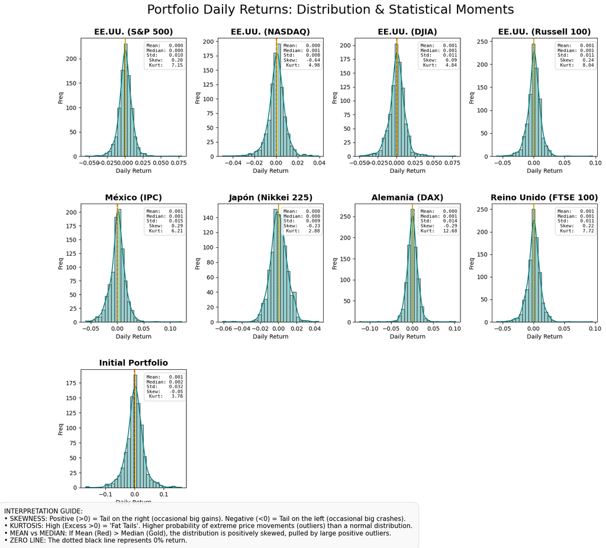

| Ticker | Mean | Median | Std Dev | Skewness | Kurtosis |
| --- | --- | --- | --- | --- | --- |
| Alemania (DAX) | 0.0004 | 0.0007 | 0.0140 | -0.2912 | 12.6830 |
| EE.UU. (Russell 100) | 0.0005 | 0.0009 | 0.0111 | 0.2379 | 8.0382 |
| Reino Unido (FTSE 100) | 0.0005 | 0.0007 | 0.0113 | 0.2242 | 7.7171 |
| EE.UU. (S&P 500) | 0.0004 | 0.0004 | 0.0095 | 0.2033 | 7.1519 |
| México (IPC) | 0.0007 | 0.0013 | 0.0147 | 0.2939 | 6.2097 |
| EE.UU. (NASDAQ) | 0.0003 | 0.0007 | 0.0080 | -0.6407 | 4.9840 |
| EE.UU. (DJIA) | 0.0005 | 0.0009 | 0.0108 | 0.0892 | 4.8448 |
| Initial Portfolio | 0.0006 | 0.0017 | 0.0318 | -0.0529 | 3.7780 |
| Japón (Nikkei 225) | 0.0004 | 0.0002 | 0.0095 | -0.2327 | 2.8813 |

```python
results_df = functions.plot_returns_distributions(merge_daily_returns, num_cols=4)
```

```python
functions.plot_daily_returns(merge_daily_returns)
```

[output not shown]

## Cumulative Returns

```python
# Combine Comulative Returns of Initial Porfolio and Benchmark Indices in a single dataFrame to plot

# convert portfolio_cumulative_returns to datafre to merge it with Indices returns
portfolio_cumulative_returns_df = pd.DataFrame(portfolio_cumulative_returns)
portfolio_cumulative_returns_df.rename(columns={'portfolio cumulative returns':'Initial Portfolio'}, inplace=True)

# check if the lenghts of the dataframes match
if len(portfolio_cumulative_returns_df) != len(cumulative_returns_bm):
    print(f"Lengths of DataFrames don't match {len(portfolio_cumulative_returns_df)} vs {len(cumulative_returns_bm)} but a left merge will help")


# Merge Cumulative Returns of Benchmark Indices and Initial Portfolio
# Note: Left-Merge on Benchmark cumulative returns because they don't operate on weekends or bank holidays
# thus we compare both benchmark and portfolio using the same labor day dates only.
merge_cumulative_returns = pd.merge(cumulative_returns_bm, portfolio_cumulative_returns_df, on='Date', how="left")
print("\nDaily Cumulative Returns (merged portfolio and indices):")
display(merge_cumulative_returns.tail(5))
```

| Date | EE.UU. (S&P 500) | EE.UU. (NASDAQ) | EE.UU. (DJIA) | EE.UU. (Russell 100) | México (IPC) | Japón (Nikkei 225) | Alemania (DAX) | Reino Unido (FTSE 100) | Initial Portfolio |
| --- | --- | --- | --- | --- | --- | --- | --- | --- | --- |
| 2026-01-06 | 34.248604 | 33.539066 | 55.726740 | 55.400121 | 71.853038 | 40.797690 | 36.248583 | 51.833991 | 35.760188 |
| 2026-01-07 | 32.983799 | 32.556259 | 57.166009 | 54.865557 | 72.123871 | 40.471716 | 34.805889 | 51.297228 | 34.245238 |
| 2026-01-08 | 33.716711 | 32.510087 | 57.198548 | 54.877411 | 71.362958 | 41.877723 | 32.614420 | 51.308437 | 35.298223 |
| 2026-01-09 | 34.362578 | 33.564123 | 58.037982 | 55.880318 | 72.759331 | 43.050503 | 34.748581 | 52.257065 | 35.244222 |
| 2026-01-14 | 34.246878 | 34.183366 | 57.202305 | 55.048952 | 71.024303 | 45.348492 | 36.741709 | 51.503084 | 30.576776 |

```python
functions.plot_cumulative_returns(merge_cumulative_returns)
```

[output not shown]

```python
# Total Cumulative Returns
print("\nTotal (Final) cumulative Returns (%):")
merge_cumulative_returns_finals = merge_cumulative_returns.iloc[-1].copy()
merge_cumulative_returns_finals.rename('Final Cumulative Returns (%)', inplace=True)
merge_cumulative_returns_finals.sort_values(ascending=False, inplace=True)
display(merge_cumulative_returns_finals)
```

```
México (IPC)              71.024303
EE.UU. (DJIA)             57.202305
EE.UU. (Russell 100)      55.048952
Reino Unido (FTSE 100)    51.503084
Japón (Nikkei 225)        45.348492
Alemania (DAX)            36.741709
EE.UU. (S&P 500)          34.246878
EE.UU. (NASDAQ)           34.183366
Initial Portfolio         30.576776
Name: Final Cumulative Returns (%), dtype: float64
```

## Volatility

```python
# Anualized Volatility of portfolio + Benchmarks
print('\nAnnualized Volatility (%):')
merge_annualized_volatility = merge_daily_returns.std() * np.sqrt(252)
merge_annualized_volatility = merge_annualized_volatility * 100
merge_annualized_volatility.rename('Annualized Volatility (%)', inplace=True)
merge_annualized_volatility.sort_values(ascending=False, inplace=True)
display(merge_annualized_volatility)
```

```
Initial Portfolio         50.472403
México (IPC)              23.318459
Alemania (DAX)            22.176649
Reino Unido (FTSE 100)    17.877556
EE.UU. (Russell 100)      17.542846
EE.UU. (DJIA)             17.213699
EE.UU. (S&P 500)          15.093692
Japón (Nikkei 225)        15.049194
EE.UU. (NASDAQ)           12.722783
Name: Annualized Volatility (%), dtype: float64
```

## Sharpe Ratio

```python
sharpe_ratio = pd.DataFrame()
sharpe_ratio['Annualized Returns (%)'] = merge_daily_returns.mean()*252*100 #Annualized returns
sharpe_ratio = pd.concat([sharpe_ratio['Annualized Returns (%)'], merge_annualized_volatility], axis=1)
sharpe_ratio['Sharpe Ratio'] = (sharpe_ratio['Annualized Returns (%)'] - (risk_free*100)) / (sharpe_ratio['Annualized Volatility (%)'])
sharpe_ratio.sort_values(by='Sharpe Ratio', ascending=False, inplace=True)
sharpe_ratio
```

|  | Annualized Returns (%) | Annualized Volatility (%) | Sharpe Ratio |
| --- | --- | --- | --- |
| EE.UU. (DJIA) | 13.726229 | 17.213699 | 0.605694 |
| México (IPC) | 17.238259 | 23.318459 | 0.597735 |
| EE.UU. (Russell 100) | 13.408435 | 17.542846 | 0.576214 |
| Reino Unido (FTSE 100) | 12.841209 | 17.877556 | 0.533698 |
| Japón (Nikkei 225) | 11.256975 | 15.049194 | 0.528731 |
| EE.UU. (NASDAQ) | 8.771307 | 12.722783 | 0.430040 |
| EE.UU. (S&P 500) | 9.109451 | 15.093692 | 0.384893 |
| Alemania (DAX) | 10.937215 | 22.176649 | 0.344381 |
| Initial Portfolio | 15.669442 | 50.472403 | 0.245073 |

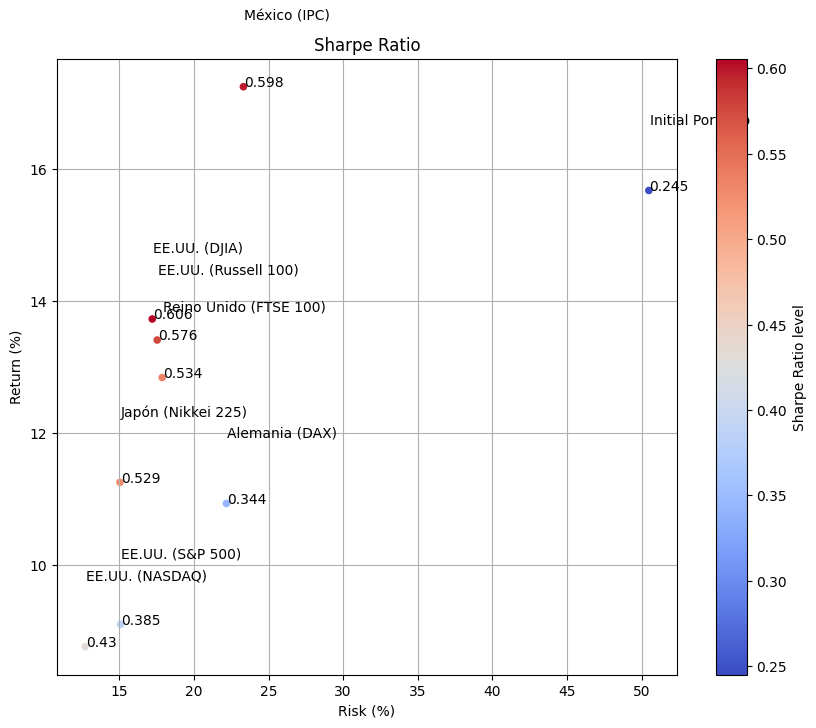

```python
#fig, ax = plt.subplots()

ax = sharpe_ratio.plot.scatter(
                        x=sharpe_ratio.columns[1],
                        y=sharpe_ratio.columns[0],
                        c=sharpe_ratio.columns[2],
                        colormap='coolwarm',
                        alpha=1.0,
                        figsize=(10,8))
for i, label in enumerate(round(sharpe_ratio['Sharpe Ratio'],3)):
    ax.text(sharpe_ratio['Annualized Volatility (%)'].iloc[i] + 0.05, sharpe_ratio['Annualized Returns (%)'].iloc[i], label)
    ax.text(sharpe_ratio['Annualized Volatility (%)'].iloc[i] + 0.05, sharpe_ratio['Annualized Returns (%)'].iloc[i] + 1, sharpe_ratio.index[i])

ax.figure.axes[1].set_ylabel('Sharpe Ratio level')

plt.title('Sharpe Ratio')
plt.xlabel('Risk (%)')
plt.ylabel('Return (%)')
plt.grid()
plt.show()
```

## Summary

```python
# Days of evaluation
no_days_compare = today.date() - first_valid_dates.iloc[0].date()
print(f"\nNumber of days of evaluation: {no_days_compare.days} days. From: {first_valid_dates.iloc[0].date().strftime("%B %d, %Y")} to: {today.date().strftime("%B %d, %Y")}")

# Summary Return, Volatility and Sharp Ratio
print("\nSummary: Benchmark Indices + Initial Portfolio")
print("\nReturns:")
print(f"'{merge_cumulative_returns_finals.index[0]}' has the largest total return {merge_cumulative_returns_finals.iloc[0]:,.5}%")
print(f"and'{merge_cumulative_returns_finals.index[-1]}' the lowest total return {merge_cumulative_returns_finals.iloc[-1]:,.3}%")
print("\nVolatility:")
print(f"'{merge_annualized_volatility.index[0]}' has the largest volatility {merge_annualized_volatility.iloc[0]:,.5}%")
print(f"and '{merge_annualized_volatility.index[-1]}' the lowest volatility {merge_annualized_volatility.iloc[-1]:,.5}%")
print("\nSharp Ratio:")
print(f"'{sharpe_ratio.index[0]}' has the best Sharpe Ratio {sharpe_ratio['Sharpe Ratio'].iloc[0]:,.4}")
print(f"and '{sharpe_ratio.index[-1]}' the worst Sharp Ratio {sharpe_ratio['Sharpe Ratio'].iloc[-1]:,.3}")
```

[output not shown]

# Buy and Hold

## B&H - Stocks (Initial Portfolio)

Initial Investment $100,000 in each Asset

```python
# B&H Stocks in initial Portfolio
functions.buy_and_hold_strategy(cumulative_returns, 100000, "Portfolio Stocks")
```

| Ticker | Initial_Value_USD | Final_Value_USD | Margin_USD | Yield_Perc |
| --- | --- | --- | --- | --- |
| GMBXF | 100,000.00 | 263,332.19 | 163,332.19 | 163.33 |
| MELI | 100,000.00 | 129,509.36 | 29,509.36 | 29.51 |

## B&H - Indices and Portfolio

Initial Investment $100,000 in each Index and Initial Portfolio

```python
# B&H Indices & Portfolio (merged)
functions.buy_and_hold_strategy(merge_cumulative_returns, 100000, "Market Benchmarks Indices and Initital Portfolio")
```

| Ticker | Initial_Value_USD | Final_Value_USD | Margin_USD | Yield_Perc |
| --- | --- | --- | --- | --- |
| México (IPC) | 100,000.00 | 171,024.30 | 71,024.30 | 71.02 |
| EE.UU. (DJIA) | 100,000.00 | 157,202.31 | 57,202.31 | 57.20 |
| EE.UU. (Russell 100) | 100,000.00 | 155,048.95 | 55,048.95 | 55.05 |
| Reino Unido (FTSE 100) | 100,000.00 | 151,503.08 | 51,503.08 | 51.50 |
| Japón (Nikkei 225) | 100,000.00 | 145,348.49 | 45,348.49 | 45.35 |
| Alemania (DAX) | 100,000.00 | 136,741.71 | 36,741.71 | 36.74 |
| EE.UU. (S&P 500) | 100,000.00 | 134,246.88 | 34,246.88 | 34.25 |
| EE.UU. (NASDAQ) | 100,000.00 | 134,183.37 | 34,183.37 | 34.18 |
| Initial Portfolio | 100,000.00 | 130,576.78 | 30,576.78 | 30.58 |

# Dollar Cost Averaging (DCA)

## DCA - Stocks (Initial Portfolio)

Monthly Investment $100 in each Asset

```python
# For individual stocks
functions.dollar_cost_averaging_strategy(prices, monthly_investment=100, title_suffix="Individual Stocks")
```

| Ticker | Total_Invested | Final_Value_USD | Margin_USD | Yield_Perc_% |
| --- | --- | --- | --- | --- |
| GMBXF | 5,800.00 | 14,100.03 | 8,300.03 | 143.10 |
| MELI | 5,800.00 | 8,719.09 | 2,919.09 | 50.33 |

## DCA - Indices

Monthly Investment $100 in each Asset

```python
# For Benchmarks and your Portfolio Index
functions.dollar_cost_averaging_strategy(benchmarks_prices, monthly_investment=100, title_suffix="Indices & Portfolio")
```

| Ticker | Total_Invested | Final_Value_USD | Margin_USD | Yield_Perc_% |
| --- | --- | --- | --- | --- |
| Alemania (DAX) | 5,800.00 | 9,590.04 | 3,790.04 | 65.35 |
| México (IPC) | 5,800.00 | 9,047.19 | 3,247.19 | 55.99 |
| EE.UU. (DJIA) | 5,800.00 | 8,635.29 | 2,835.29 | 48.88 |
| EE.UU. (Russell 100) | 5,800.00 | 8,346.89 | 2,546.89 | 43.91 |
| Reino Unido (FTSE 100) | 5,800.00 | 8,283.80 | 2,483.80 | 42.82 |
| EE.UU. (S&P 500) | 5,800.00 | 7,672.65 | 1,872.65 | 32.29 |
| EE.UU. (NASDAQ) | 5,800.00 | 7,510.08 | 1,710.08 | 29.48 |
| Japón (Nikkei 225) | 5,800.00 | 7,343.83 | 1,543.83 | 26.62 |

# Momentum

Applied to all **Stocks** in Initial Portfolio

```
Ticker
GMBXF    163.3
MELI      29.5
Name: Final Cumulative Returns (%), dtype: float64
```

```
Ticker
MELI      29.5
GMBXF    163.3
Name: Final Cumulative Returns (%), dtype: float64
```

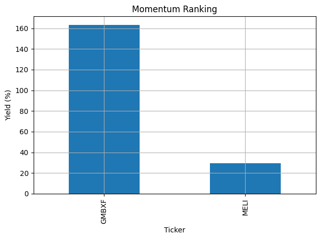

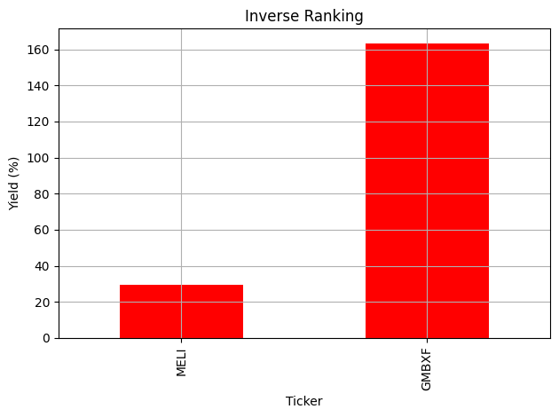

```python
# call the DataFrame of the Final Cumulative Returns, which is the total return of each asset in the period.
cumulative_returns_final

# MOMENTUM: Order from largest to lowest return
momentum_ranking = cumulative_returns_final.sort_values(ascending=False)
print("Momentum Ranking (Annual yield):")
display(momentum_ranking)

# Inverse Ranking
inverse_ranking = cumulative_returns_final.sort_values(ascending=True)
print("Inverse Momentum Ranking (Annual yield):")
display(inverse_ranking)


# Plot Momentum and Inverse momentum

plt.Figure(figsize=(12, 9))
momentum_ranking.plot(kind='bar', title='Momentum Ranking')
plt.ylabel('Yield (%)')
plt.grid(True)
plt.tight_layout()
plt.show()

plt.Figure(figsize=(12, 9))
inverse_ranking.plot(kind='bar', title='Inverse Ranking', color='red')
plt.ylabel('Yield (%)')
plt.grid(True)
plt.tight_layout()
plt.show()
```

Applied to Indices

```
México (IPC)              71.024303
EE.UU. (DJIA)             57.202305
EE.UU. (Russell 100)      55.048952
Reino Unido (FTSE 100)    51.503084
Japón (Nikkei 225)        45.348492
Alemania (DAX)            36.741709
EE.UU. (S&P 500)          34.246878
EE.UU. (NASDAQ)           34.183366
Name: final cumulative returns Benchmarks (%), dtype: float64
```

```
EE.UU. (NASDAQ)           34.183366
EE.UU. (S&P 500)          34.246878
Alemania (DAX)            36.741709
Japón (Nikkei 225)        45.348492
Reino Unido (FTSE 100)    51.503084
EE.UU. (Russell 100)      55.048952
EE.UU. (DJIA)             57.202305
México (IPC)              71.024303
Name: final cumulative returns Benchmarks (%), dtype: float64
```

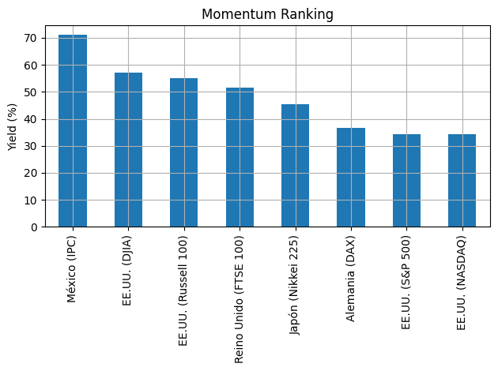

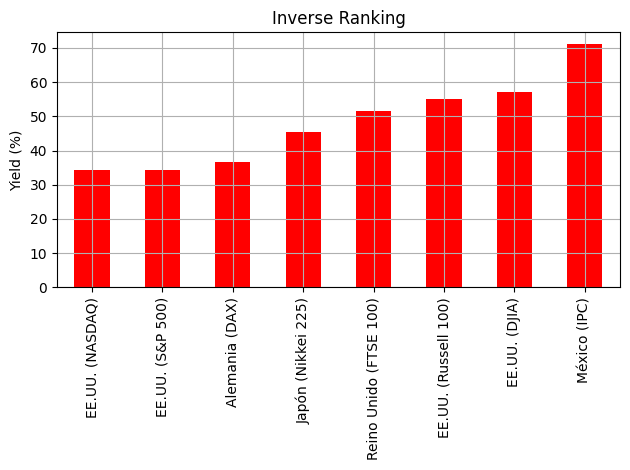

```python
# call the DataFrame of the Final Cumulative Returns, which is the total return of each Index in the period.
cumulative_returns_final_bm

# MOMENTUM: Order from largest to lowest return
momentum_ranking_bm = cumulative_returns_final_bm.sort_values(ascending=False)
print("Momentum Ranking (Annual yield) of Benchmark Indices:")
display(momentum_ranking_bm)

# Inverse Ranking
inverse_ranking_bm = cumulative_returns_final_bm.sort_values(ascending=True)
print("Inverse Momentum Ranking (Annual yield) of Benchmark Indices:")
display(inverse_ranking_bm)

# Plot Momentum and Inverse momentum
plt.Figure(figsize=(12, 9))
momentum_ranking_bm.plot(kind='bar', title='Momentum Ranking')
plt.ylabel('Yield (%)')
plt.grid(True)
plt.tight_layout()
plt.show()

plt.Figure(figsize=(12, 9))
inverse_ranking_bm.plot(kind='bar', title='Inverse Ranking', color='red')
plt.ylabel('Yield (%)')
plt.grid(True)
plt.tight_layout()
plt.show()
```

# Correlation

## Correlation equation

Pearson correlation coefficient:

$$\rho_{X,Y} = \frac {cov(X,Y)}{\sigma_X \sigma_Y} = \frac{E[(X-\mu_X)(Y-\mu_Y)]}{\sigma_X \sigma_Y}$$

$$ \sigma_p^2 = w_A^2 \sigma_A^2 \;+\; w_B^2 \sigma_B^2 \;+\; 2\,w_A w_B\,\rho_{AB}\,\sigma_A \sigma_B $$

## Stocks

```python
functions.plot_interactive_heatmap_correlation(daily_returns, triangle='half')
functions.plot_extreme_correlations(daily_returns, num_pairs=10)
```

| Pair | Correlation (r) | R-Squared | p-value | Slope (Beta) | Std Error | Intercept (Alpha) | Vol_MELI | Vol_GMBXF | Significant? |
| --- | --- | --- | --- | --- | --- | --- | --- | --- | --- |
| MELI vs GMBXF | 0.1905 | 0.0363 | 0.0000 | 0.1713 | 0.0256 | 0.0011 | 0.0315 | 0.0283 | Yes |

## Indices & Portfolio

```python
functions.plot_interactive_heatmap_correlation(merge_daily_returns, triangle='half')
functions.plot_extreme_correlations(merge_daily_returns, num_pairs=10)
```

| Pair | Correlation (r) | R-Squared | p-value | Slope (Beta) | Std Error | Intercept (Alpha) | Vol_Reino Unido (FTSE 100) | Vol_EE.UU. (Russell 100) | Significant? | Vol_México (IPC) | Vol_EE.UU. (S&P 500) | Vol_EE.UU. (DJIA) | Vol_EE.UU. (NASDAQ) | Vol_Initial Portfolio |
| --- | --- | --- | --- | --- | --- | --- | --- | --- | --- | --- | --- | --- | --- | --- |
| Reino Unido (FTSE 100) vs EE.UU. (Russell 100) | 0.9891 | 0.9783 | 0.0000 | 0.9706 | 0.0047 | 0.0000 | 0.0113 | 0.0110 | Yes | nan | nan | nan | nan | nan |
| México (IPC) vs EE.UU. (Russell 100) | 0.9603 | 0.9221 | 0.0000 | 0.7224 | 0.0069 | 0.0000 | nan | 0.0110 | Yes | 0.0147 | nan | nan | nan | nan |
| Reino Unido (FTSE 100) vs México (IPC) | 0.9509 | 0.9043 | 0.0000 | 1.2404 | 0.0132 | 0.0001 | 0.0113 | nan | Yes | 0.0147 | nan | nan | nan | nan |
| EE.UU. (Russell 100) vs EE.UU. (S&P 500) | 0.9229 | 0.8518 | 0.0000 | 0.7941 | 0.0109 | -0.0001 | nan | 0.0110 | Yes | nan | 0.0095 | nan | nan | nan |
| Reino Unido (FTSE 100) vs EE.UU. (S&P 500) | 0.9152 | 0.8376 | 0.0000 | 0.7727 | 0.0112 | -0.0000 | 0.0113 | nan | Yes | nan | 0.0095 | nan | nan | nan |
| México (IPC) vs EE.UU. (S&P 500) | 0.8072 | 0.6516 | 0.0000 | 0.5225 | 0.0125 | 0.0000 | nan | nan | Yes | 0.0147 | 0.0095 | nan | nan | nan |
| EE.UU. (DJIA) vs EE.UU. (NASDAQ) | 0.7612 | 0.5794 | 0.0000 | 0.5626 | 0.0157 | 0.0000 | nan | nan | Yes | nan | nan | 0.0108 | 0.0080 | nan |
| Initial Portfolio vs México (IPC) | 0.6171 | 0.3809 | 0.0000 | 0.2851 | 0.0119 | 0.0005 | nan | nan | Yes | 0.0147 | nan | nan | nan | 0.0318 |
| Initial Portfolio vs Reino Unido (FTSE 100) | 0.5783 | 0.3345 | 0.0000 | 0.2048 | 0.0095 | 0.0004 | 0.0113 | nan | Yes | nan | nan | nan | nan | 0.0318 |
| Initial Portfolio vs EE.UU. (Russell 100) | 0.5745 | 0.3300 | 0.0000 | 0.1997 | 0.0093 | 0.0004 | nan | 0.0110 | Yes | nan | nan | nan | nan | 0.0318 |

# Covariance

- La matriz de covarianza es la base para calcular la varianza del portafolio:

$$ \sigma_p^2 = w^T \Sigma w $$

donde:

- w = vector de pesos del portafolio.
- $\Sigma = matriz$ de covarianzas.
- Un gestor de portafolios busca combinaciones de activos con **baja covarianza** para reducir la volatilidad total manteniendo el rendimiento esperado.
- Covariance:$$ \text{Cov}(X,Y) = E[(X - \mu_X)(Y - \mu_Y)]$$
- Values:
  - Positive → one rises, other rises too.
  - Negative → one rises, other goes down.
  - near 0 → there's no clear relationtip.

## Stocks

```python
# Plot ANNUALIZED variance/covariance Matrix =  returns.cov() * 252
functions.plot_annualized_covariance_heatmap(daily_returns, triangle='half')
```

## Indices & Portfolio

```python
# Plot ANNUALIZED variance/covariance Matrix =  returns.cov() * 252
functions.plot_annualized_covariance_heatmap(merge_daily_returns, triangle='half')
```

# Efficient Frontier (Sharpe Ratio)

$$ Sharpe = \frac{R_p - R_f}{\sigma_p} = \frac{\mu_p - r_f}{\sigma_p}$$

Where:

- $R_p$: Expected Portfolio Return, $\mu$
- $R_f$: Risk Free Rate (can be 0 if ignored)
- $\sigma_p$: Portfolio Risk (StdDev)

Long-only: weights $\,w_i\in[0,1]$ y $\sum w_i=1$.

- Only purchases, no leverage (by shorting)
- Pros: Less operating risk
- Cons: Frontier less efficient than with shorts (due leverage)

Shorts allowed: weights $\,w_i\in[-1,1]$ y $\sum w_i=1 \text{ (or similar)}$.

- One can short sell and compensate with long positions
- Pros: Theoretical improvement of the Frontier with more options
- Cons:: Implied leverage, Margin requirements, Costs and Operational Risk

## Stocks

```python
# --- EFFICIENT FRONTIER & CAPITAL MARKET LINE ANALYSIS---

import functions # => .../functions.ipynb     file attached
importlib.reload(functions) # Reloads the module

functions.run_full_frontier_analysis(rets=daily_returns,
                          curr_port_weights = weights_df['Weights'],
                          curr_port_vol = portfolio_annualized_volatility,
                          curr_port_ret = portfolio_annualized_return,
                          mean_ann = daily_returns.mean() * 252,
                          cov_ann = daily_returns.cov() * 252,
                          rf_default = risk_free,
                          long_only = True,  # Set to True for standard long-only constraints
                          portfolio_value = Total_invested, #70000
                          yields = yields/100
                          )
```

```
VBox(children=(FloatText(value=211300.0, description='Portfolio Value (V): $', layout=Layout(width='350px'), s…
```

Number of starts: To avoid local minimas. 10-25 normal (fast and robust), 50-100 (for large amount of stocks)

```python
no_starts = 25
no_simul = 2000000
```

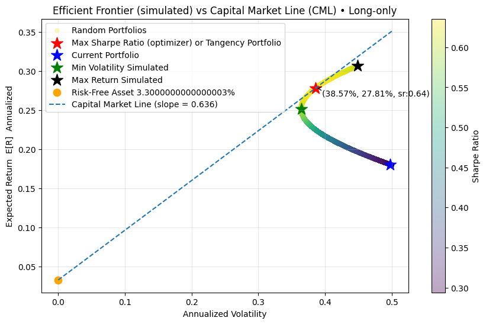

```python
weights_optimal, vol_ret_sr_optimal = functions.efficient_froentier_sharp_ratio(
                daily_returns,
                [portfolio_annualized_volatility, portfolio_annualized_return],
                daily_returns.mean()*252, # Simple Arithmetic Mean Annualization
                daily_returns.cov()*252, #Annualized Covariance
                risk_free, #Risk Free
                True, # Long only = True, Short allowed = False
                no_starts, # no. of starts (25 default)
                no_simul, # no. of simulations
                123 # seed
                )
```

### Positions from current to optimal

```python
# Recall Total Invested
Investment = Total_invested

# Current Portolio Weights and Positions
weights_df

# Optimal Weights from Efficient Frontier
weights_optimal

# Merge DataFrames
weights_df_Optimal = pd.merge(weights_df, weights_optimal, left_index=True, right_index=True, how='outer')

# New Investment (USD)
weights_df_Optimal['New Investment usd'] = weights_df_Optimal['Optimal Weights'] * Investment

# New QTY
weights_df_Optimal['New QTY'] = weights_df_Optimal['New Investment usd'] / weights_df_Optimal['Close Price']

# Difference in QTY or buy/sell position
weights_df_Optimal['Position_to_Optimal'] = weights_df_Optimal['New QTY'] - weights_df_Optimal['Current QTY']

weights_df_Optimal = round(weights_df_Optimal, 3)
display(weights_df_Optimal)

print(f"Current Investment: $ {round(Investment, 2)}")
print(f"New Investment: $ {round(weights_df_Optimal['New Investment usd'].sum(), 2)}")
```

| Ticker | Current QTY | Close Price | Investment | Weights | Optimal Weights | New Investment usd | New QTY | Position_to_Optimal |
| --- | --- | --- | --- | --- | --- | --- | --- | --- |
| GMBXF | 100 | 11.05 | 1105.000 | 0.005 | 0.776 | 163884.276 | 14831.156 | 14731.156 |
| MELI | 100 | 2101.95 | 210194.995 | 0.995 | 0.224 | 47415.719 | 22.558 | -77.442 |

## Including Risk Free Asset

Once you have the tangency portfolio 𝑤𝑡 (long-only), the fraction of your wealth 𝑋 to put into the risky portfolio is 𝑦.

Choose 𝑦 based on your target volatility, target return, or risk-aversion:

- Objective 1. Target Volatility:

$$ 𝑦 = \frac{𝜎_𝑝}{𝜎_𝑡} $$

- Objective 2. Target Return:

$$ 𝑦 = \frac{𝐸_𝑝 − 𝑅_𝑓}{𝐸[𝑅_𝑡] − 𝑅_𝑓} $$

- Objective 3. Mean-Variance Utility (Expected Utility Funcion):

$$ U = E[R_p] - \frac{1}{2} \gamma \sigma_p^{2} $$

$$ 𝑦* = \frac{𝐸[𝑅_𝑡] − 𝑅_𝑓}{𝛾 𝜎_𝑡^{2}}$$

U : “Utility” — a scalar number representing the investor’s satisfaction from a portfolio. Its a parabolic function, higher gama the steeper the curve, thus more return expected for unit of risk.

𝛾 > 0: Risk aversion coefficient, a measure of how strongly the investor dislikes risk. Penalizes risk. Higher->more conservative.

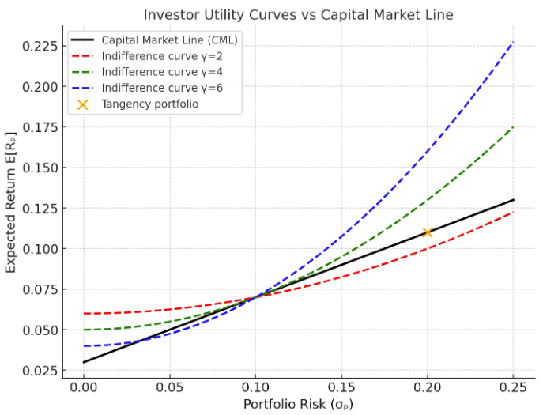

Finally: invest 𝑦𝑋 in 𝑤_𝑡 and (1−𝑦)𝑋 in the risk-free asset, enforcing 0≤𝑦≤1 for long-only/no-borrowing.

```python
# Objective 1. You want a target portfolio volatility 𝜎𝑝 :

# 𝜎𝑝 (target volatility):
# 90% of the Tangency portfolio volatility (can be any value)
target_volatility = vol_ret_sr_optimal[0] * 0.90

# The fraction of total wealth X invested in the tangency (risky) portfolio
y = target_volatility / vol_ret_sr_optimal[0]

print(f"Target Volatility: {target_volatility:.2%}")
print(f"The fraction of total wealth X invested in the tangency (risky) portfolio 'y' is: {y:.2%}, that is ${y*Total_invested:,.2f}usd")
print(f"The fraction invested in the risk-free asset (1-y) is: {1-y:.2%}, that is ${(1-y)*Total_invested:,.2f}usd")
ER_p = risk_free + y*(vol_ret_sr_optimal[1] - risk_free)
print(f"Expected Return E[Rp] = {ER_p:.2%}")
print(f"Sharpe Ratio = {(ER_p - risk_free) / target_volatility:.2f} ")
```

[output not shown]

```python
# Objective 2. You want a target expected return Ep

# Ep (target Expected Return):
# 90% of the Tangency portfolio return (can be any value)
target_return = vol_ret_sr_optimal[1] * 0.90

# The fraction of total wealth X invested in the tangency (risky) portfolio
y = (target_return - risk_free) / (vol_ret_sr_optimal[1] - risk_free)

print(f"Target Expected Return: {target_return:.2%}")
print(f"The fraction of total wealth X invested in the tangency (risky) portfolio 'y' is: {y:.2%}, that is ${y*Total_invested:,.2f}usd")
print(f"The fraction invested in the risk-free asset (1-y) is: {1-y:.2%}, that is ${(1-y)*Total_invested:,.2f}usd")
sigma_p = y * vol_ret_sr_optimal[0]
print(f"Volatility: {sigma_p:.2%}")
print(f"Sharpe Ratio = {(target_return - risk_free)/sigma_p:.2f}")
```

[output not shown]

```python
# Objective 3. You maximize mean–variance Utility (risk aversion 𝛾)

# Gamma (risk aversion coefficient) :
# If 𝛾 is large, the investor is very risk averse — even small increases in variance are penalized heavily.
# → They prefer portfolios with lower volatility, even if returns are modest.
# If 𝛾 is small, the investor is risk tolerant (or aggressive) — they are willing to accept more variance for more expected return.
gamma = 4

# a) Allowing borrowing (short)
# The fraction of total wealth X invested in the tangency (risky) portfolio
y_star = (vol_ret_sr_optimal[1] - risk_free) / (gamma * (vol_ret_sr_optimal[0]**2))
print("a) Allowing borrowing (short in risk asset):")
print(f"Mean-variance risk aversion coefficient: {gamma}")
print(f"The fraction of total wealth X invested in the tangency (risky) portfolio y* is: {y_star:.2%}, that is ${y_star * Total_invested:,.2f}usd")
print(f"The fraction invested in the risk-free asset (1-y*) is: {1-y:.2%}, that is ${(1-y_star) * Total_invested:,.2f}usd")
# E[R_p] = Rf + y* (E[Rt] - Rf)
ER_p = risk_free + (y_star * (vol_ret_sr_optimal[1] - risk_free))
sigma_p = y_star * vol_ret_sr_optimal[0]
print(f"Expected Return E[Rp] = {ER_p:.2%}")
print(f"Volatility sigma_p = {sigma_p:.2%}")
print(f"Sharpe Ratio = {(ER_p - risk_free)/sigma_p:.2}")

# b) For long-only, no-borrowing constraint: set 𝑦=min(1,max(0,𝑦∗)).
y = min(1, max(0, y_star))
print("\nb) For long-only, no-borrowing constraint:")
print(f"Mean-variance risk aversion coefficient: {gamma}")
print(f"The fraction of total wealth X invested in the tangency (risky) portfolio 'y' is: {y:.2%}, that is ${y*Total_invested:,.2f}usd")
print(f"The fraction invested in the risk-free asset (1-y) is: {1-y:.2%}, that is ${(1-y)*Total_invested:,.2f}usd")
ER_p = risk_free + (y * (vol_ret_sr_optimal[1] - risk_free))
sigma_p = y * vol_ret_sr_optimal[0]
print(f"Expected Return E[Rp] = {ER_p:.2%}")
print(f"Volatility sigma_p = {sigma_p:.2%}")
print(f"Sharpe Ratio = {(ER_p - risk_free)/sigma_p:.2}")
```

[figure not shown]

## Indices & Portfolio

```python
# ANNUAL DIVIDEND YIELDS
yields_merge = functions.plot_annual_dividnd_yields(merge_daily_returns)
```

[output not shown]

```
EE.UU. (S&P 500)          0
EE.UU. (NASDAQ)           0
EE.UU. (DJIA)             0
EE.UU. (Russell 100)      0
México (IPC)              0
Japón (Nikkei 225)        0
Alemania (DAX)            0
Reino Unido (FTSE 100)    0
Initial Portfolio         0
Name: dividendYield, dtype: int64
```

```python
# --- EFFICIENT FRONTIER & CAPITAL MARKET LINE ANALYSIS---

import functions # => .../functions.ipynb     file attached
importlib.reload(functions) # Reloads the module

functions.run_full_frontier_analysis(rets = merge_daily_returns,
                          curr_port_weights = weights_df['Weights'],
                          curr_port_vol = portfolio_annualized_volatility,
                          curr_port_ret = portfolio_annualized_return,
                          mean_ann = merge_daily_returns.mean() * 252,
                          cov_ann = merge_daily_returns.cov() * 252,
                          rf_default = risk_free,
                          long_only = True,  # Set to True for standard long-only constraints
                          portfolio_value = Total_invested, #100000
                          yields = yields_merge/100
                          )
```

```
VBox(children=(FloatText(value=211300.0, description='Portfolio Value (V): $', layout=Layout(width='350px'), s…
```

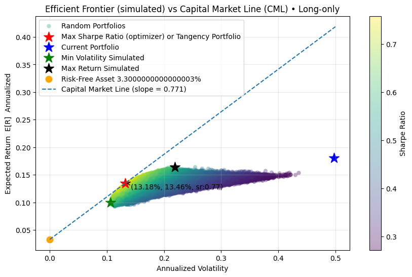

```python
weights_optimal, vol_ret_sr_optimal = functions.efficient_froentier_sharp_ratio(
                merge_daily_returns,
                [portfolio_annualized_volatility, portfolio_annualized_return],
                merge_daily_returns.mean()*252, # Simple Arithmetic Mean Annualization
                merge_daily_returns.cov()*252, #Annualized Covariance
                risk_free, #Risk Free
                True, # Long only = True, Short allowed = False
                no_starts, # no. of starts (25 default)
                no_simul, # no. of simulations
                123 # seed
                )
```

## **TO-DO: Include GUI and "make your own portfolio" with a variety of Stocks to choose.

(see Frontera Eficiente for GUI)

# Indicators: alpha, Beta, R^2, SR, Sortino, VaR, CVaR - vs with Benchmark

| Métrica | Valor Óptimo / Bueno | Interpretación |
| --- | --- | --- |
| **Alpha (α)** | > 0 (ideal: +2% a +10% anual) | Exceso de retorno sobre lo esperado por el CAPM; positivo indica valor agregado. |
| **Beta (β)** | ≈ 1 (mercado), <1 defensivo, >1 agresivo | Sensibilidad al mercado; >1 = más volátil, <1 = más estable. |
| **R² (correlación)** | > 0.8 (80% o más) | El portafolio se mueve casi igual que el benchmark (muy “indexado”). |
| **R² (correlación)** | 0.6 – 0.8 | Buena relación con el mercado, pero con diferencias notables. |
| **R² (correlación)** | < 0.30 | El portafolio se comporta muy distinto al mercado (alta independencia). |
| **µ (Retorno anual)** | > 8% estable, > 15% agresivo | Rendimiento esperado anualizado del portafolio. |
| **σ (Volatilidad anual)** | 10%–20% moderado, <10% defensivo, >25% muy riesgoso | Mide el riesgo total (desviación estándar). |
| **Sharpe Ratio** | > 1 bueno, > 1.5 muy bueno, > 2 excelente | Retorno ajustado por riesgo total. |
| **Sortino Ratio** | > 2 excelente | Retorno ajustado por riesgo a la baja (mejor si >> Sharpe). |
| **VaR (95%, 1d)** | < 2% | Pérdida máxima esperada en un día con 95% de confianza. |
| **CVaR (95%, 1d)** | < 3% | Pérdida promedio en los peores días (cola izquierda de la distribución). |

```python
#recall
display(benchmark_indices)
```

```
{'EE.UU. (S&P 500)': '^GSPC',
 'EE.UU. (NASDAQ)': '^IXIC',
 'EE.UU. (DJIA)': '^DJI',
 'EE.UU. (Russell 100)': '^RUI',
 'México (IPC)': '^MXX',
 'Japón (Nikkei 225)': '^N225',
 'Alemania (DAX)': '^GDAXI',
 'Reino Unido (FTSE 100)': '^FTSE'}
```

|  | μ anual | σ anual | Sharpe | Sortino |
| --- | --- | --- | --- | --- |
| Current Portfolio | 0.1806 | 0.4974 | 0.2967 | 0.4864 |
| Portafolio (max SR) | 0.2781 | 0.3857 | 0.6355 | 1.0914 |
| Benchmark [^GSPC] | 0.1214 | 0.1703 | 0.5191 | NaN |

|  | Alpha (anual) | Beta | R² | VaR 1d | CVaR 1d |
| --- | --- | --- | --- | --- | --- |
| Current Portfolio | 0.0012 | 1.6550 | 0.3212 | 0.0502 | 0.0728 |
| Portafolio (max SR) | 0.1618 | 0.9422 | 0.1732 | 0.0382 | 0.0518 |

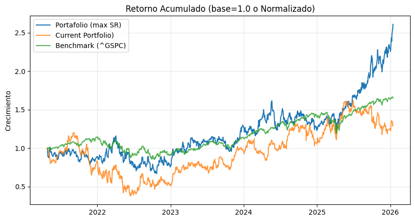

```python
# Choose a benchmark to compare for alpha, beta, R2...
index_benchmark = 0

functions.indicators(tickers, start_date, today, benchmark_indices, index_benchmark,
                     risk_free, portfolio_weights=pd.Series(weights_df['Weights']), no_starts=no_starts)
```

## ** TO-DO: EN Metricas Anualizadas incluir de forma automatica los otros 6 benchmarks

# TO-DO: CAPM (en archivo de Indicadores)

# CAPM (Capital Asset Pricing Model)

CAPM Equation:

$$ r_{i} = r_{f} + \beta_{im}*(r_{m}-r_{f}) $$

**where** :  
$r_i = $ Expected Asset Return  
$r_f = $ Risk-free asset Return  
$\beta_{i,m} = $ Asset Beta w.r.t market  
$r_m = $ Market Return

Risk-free is the minimum Return an Investor can accept.  
Difference between $r_{m}$ and $r_{f}$ is the Premium that the investor recieves by taking the risk (**equity risk Premium**).  
**$\beta$** measures the cuantity of Risk of an asset with respect to the Market.

### Asset Beta ( $\beta$ )

$$\beta = \frac{\text{Cov(}r_A, r_m\text{)}}{Var(r_m)} = \frac{\sigma_{A,m}}{\sigma_m^2} = \frac{ρ_{A,m} σ_m σ_A}{\sigma_m^2} = \frac{ρ_{A,m}σ_A}{\sigma_m}$$